# Data preparation

Camille Crapart

2023-06-13

```r
library(raster)
library(sf)
library(dplyr)
library(ggplot2)
library(colorspace)
library(directlabels)
library(RColorBrewer)
library(ggpubr)

library(spdep)
library(spatialreg)
```

# 1 Northern Lakes Survey Data 1995

## 1.1 Data from NOFA database

The data used here has been prepared in @Crapart2023.

```r
catchment.poly <- readRDS("catchment.poly.Rdata")
toc.df <- readRDS("toc.df.Rdata")
runoff <- readRDS("runoff.fennoscandia.rds")
```

## 1.2 Historical land-cover data

HILDA data are downloaded from https://www.wur.nl/en/research-results/chair-groups/environmental-sciences/laboratory-of-geo-information-science-and-remote-sensing/models/hilda/hilda-data-downloads.html

```r
hilda.raster <- "HILDA_plus_decadal.nc" %>% raster()
raster(hilda.raster)

hilda.1999 <- raster::extract(hilda.raster, layer = 11, catchment.poly[1,])

saveRDS(hilda.1999, "hilda.1999.fns.rds")
```

Hilda categories:

- 77: Water
- 66: Other land
- 55: Grass/schrubland
- 45: Forest, mixed
- 44: Forest, deciduous broad leaf
- 43: Forest: deciduous needle
- 42: Forest, evergreen borad leaf
- 41: Forest, evergreen needle
- 40: Forest, other
- 33: Pasture
- 22: Cropland
- 11: Urban

```r
hilda.1999 <- readRDS("hilda.1999.fns.rds")
hilda.tab <- sapply(hilda.1999, function(x) tabulate(x,77))
hilda.tab.area <- hilda.tab*prod(res(hilda.raster))
catchment.area <- colSums(hilda.tab.area)
hilda.tab.prop <- sweep(hilda.tab.area,2,catchment.area, FUN = "/")
names(hilda.tab.prop) <- catchment.poly$ebint
saveRDS(hilda.tab.prop,"hilda.tab.prop.Rdata")

forest <- colSums(hilda.tab.prop[c(40,41,42,43,44,45),]) %>% as.data.frame() %>% setNames("forest") %>% tibble::rownames_to_column(var = "ebint")
saveRDS(forest,"forest.rds")
```

## 1.3 Sulfur deposition data

Sulfur data is historical date modelled with the NorESM model, downloaded from CIMP5, kg/m2/s

Research criteria:

- CIMP5 models
- historical
- r1i1p1
- NorESM1

```r
catchment.poly <- readRDS("catchment.poly.Rdata")

dryso2 <- raster::stack("Sdep/dryso2_aero_NorESM1-ME_historical_r1i1p1_185001-200512.nc", bands = c(1681:1812)) %>% mean() # year 1990-2000
dryso4 <- raster::stack("Sdep/dryso4_aero_NorESM1-ME_historical_r1i1p1_185001-200512.nc", bands = c(1681:1812)) %>% mean()
wetso2 <- raster::stack("Sdep/wetso2_aero_NorESM1-ME_historical_r1i1p1_185001-200512.nc", bands = c(1681:1812)) %>% mean()
wetso4 <- raster::stack("Sdep/wetso4_aero_NorESM1-ME_historical_r1i1p1_185001-200512.nc", bands = c(1681:1812)) %>% mean()

dryso2.df <- extract(dryso2, catchment.poly, sp = T, df = T, na.rm = T, fun = mean)
names(dryso2.df) <- c("ebint","dso2")
dryso4.df <- extract(dryso4, catchment.poly, sp = T, df = T, na.rm = T, fun = mean)
names(dryso4.df) <- c("ebint","dso4")
wetso2.df <- extract(wetso2, catchment.poly, sp = T, df = T, na.rm = T, fun = mean)
names(wetso2.df) <- c("ebint","wso2")
wetso4.df <- extract(wetso4, catchment.poly, sp = T, df = T, na.rm = T, fun = mean)
names(wetso4.df) <- c("ebint","wso4")

sdep.df <- merge(dryso2.df, dryso4.df, by = "ebint") %>% merge(wetso2.df, by = "ebint") %>% merge(wetso4.df, by = "ebint")
sdep.df$tsdep <- rowSums(sdep.df@data[,c(2:5)])

saveRDS(sdep.df, "sdep.df.1995.rds")
```

```r
catchment.poly <- readRDS("catchment.poly.Rdata")

wsdep.stack <- raster::stack(
  raster("Sdep/EMEP01_rv4.45_year.1990met_1990emis_rep2022.nc", varname = "WDEP_SOX"),
  raster("Sdep/EMEP01_rv4.45_year.1991met_1991emis_rep2022.nc", varname = "WDEP_SOX"),
  raster("Sdep/EMEP01_rv4.45_year.1992met_1992emis_rep2022.nc", varname = "WDEP_SOX"),
  raster("Sdep/EMEP01_rv4.45_year.1993met_1993emis_rep2022.nc", varname = "WDEP_SOX"),
  raster("Sdep/EMEP01_rv4.45_year.1994met_1994emis_rep2022.nc", varname = "WDEP_SOX"),
  raster("Sdep/EMEP01_rv4.45_year.1995met_1995emis_rep2022.nc", varname = "WDEP_SOX"),
  raster("Sdep/EMEP01_rv4.45_year.1996met_1996emis_rep2022.nc", varname = "WDEP_SOX"),
  raster("Sdep/EMEP01_rv4.45_year.1997met_1997emis_rep2022.nc", varname = "WDEP_SOX"),
  raster("Sdep/EMEP01_rv4.45_year.1998met_1998emis_rep2022.nc", varname = "WDEP_SOX"),
  raster("Sdep/EMEP01_rv4.45_year.1999met_1999emis_rep2022.nc", varname = "WDEP_SOX")) %>% mean()

wsdep.1995 <- extract(wsdep.stack, catchment.poly, sp = T, df = T, na.rm = T, fun = mean)
names(wsdep.1995) <- c("ebint","wsdep")
saveRDS(wsdep.1995, "wsdep.1995.rds")

dsdep.stack <- raster::stack(
  raster("Sdep/EMEP01_rv4.45_year.1990met_1990emis_rep2022.nc", varname = "DDEP_SOX_m2Grid"),
  raster("Sdep/EMEP01_rv4.45_year.1991met_1991emis_rep2022.nc", varname = "DDEP_SOX_m2Grid"),
  raster("Sdep/EMEP01_rv4.45_year.1992met_1992emis_rep2022.nc", varname = "DDEP_SOX_m2Grid"),
  raster("Sdep/EMEP01_rv4.45_year.1993met_1993emis_rep2022.nc", varname = "DDEP_SOX_m2Grid"),
  raster("Sdep/EMEP01_rv4.45_year.1994met_1994emis_rep2022.nc", varname = "DDEP_SOX_m2Grid"),
  raster("Sdep/EMEP01_rv4.45_year.1995met_1995emis_rep2022.nc", varname = "DDEP_SOX_m2Grid"),
  raster("Sdep/EMEP01_rv4.45_year.1996met_1996emis_rep2022.nc", varname = "DDEP_SOX_m2Grid"),
  raster("Sdep/EMEP01_rv4.45_year.1997met_1997emis_rep2022.nc", varname = "DDEP_SOX_m2Grid"),
  raster("Sdep/EMEP01_rv4.45_year.1998met_1998emis_rep2022.nc", varname = "DDEP_SOX_m2Grid"),
  raster("Sdep/EMEP01_rv4.45_year.1999met_1999emis_rep2022.nc", varname = "DDEP_SOX_m2Grid")) %>% mean()

dsdep.1995 <- extract(dsdep.stack, catchment.poly, sp = T, df = T, na.rm = T, fun = mean)
names(dsdep.1995) <- c("ebint","dsdep")
saveRDS(dsdep.1995, "dsdep.1995.rds")

sdep.1995 <- merge(wsdep.1995, dsdep.1995, by = "gid")
sdep.1995$tsdep <- sdep.1995$wsdep + sdep.1995$dsdep
saveRDS(sdep.1995, "sdep.1995.rds")
```

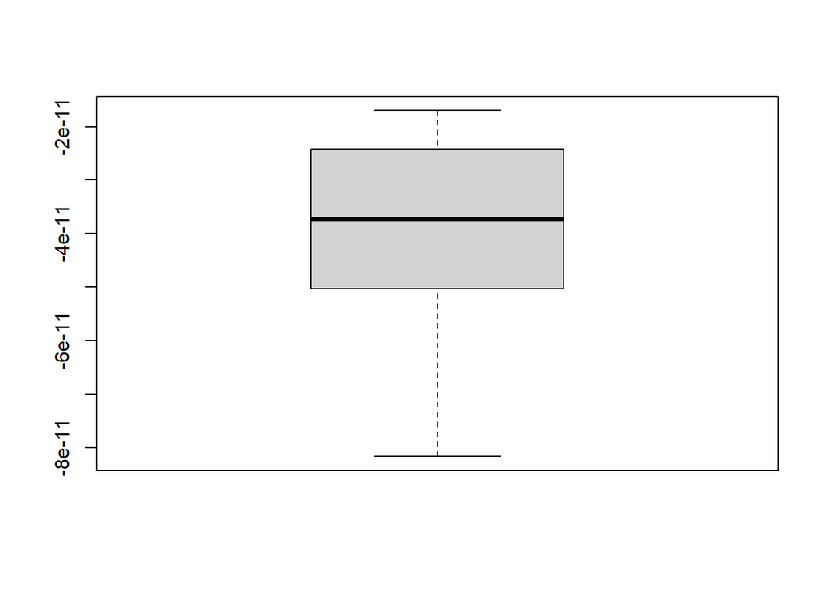

```r
sdep.df.1995 <- readRDS("sdep.df.1995.rds")
sdep.1995 <- readRDS("sdep.1995.rds")

boxplot(sdep.df.1995$tsdep)
```

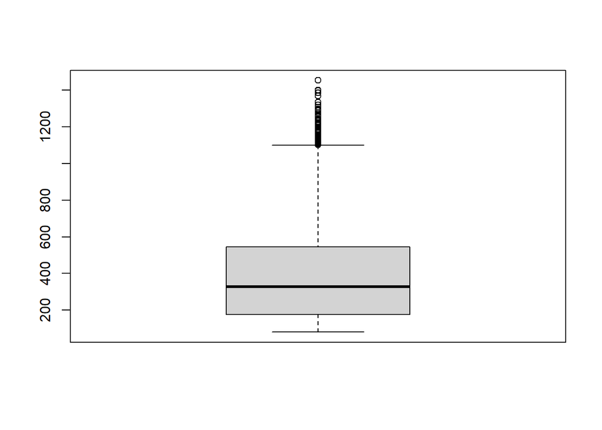

```r
boxplot(sdep.1995$tsdep)
```

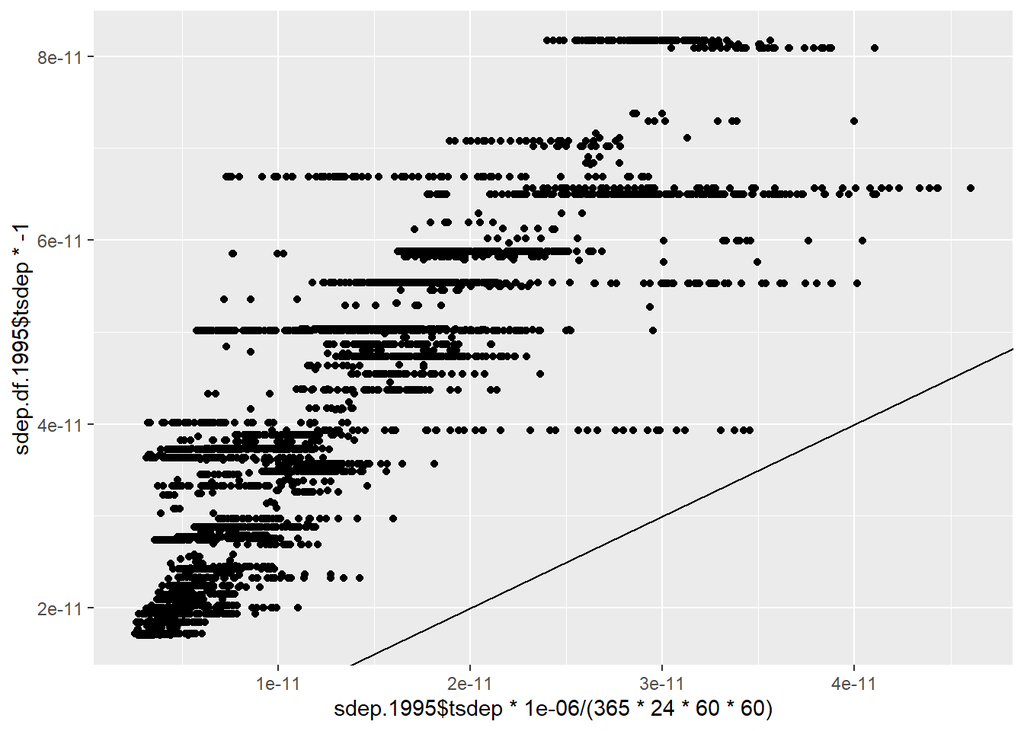

```r
qplot(sdep.1995$tsdep*1e-6/(365*24*60*60), sdep.df.1995$tsdep*-1)+geom_abline(slope = 1, intercept = 0)
```

## 1.4 Runoff, 10 years average

```r
runoff.raster <- "mrros_Lmon_CNRM-CM6-1-HR_historical_r1i1p1f2_gr_185001-201412.nc"

runoff.stack <- raster::stack(runoff.raster, bands = c(1681:1812))
runoff.mean <- runoff.stack %>% mean()

runoff.1995 <- raster::extract(runoff.mean, catchment.poly, fun = mean, df = T, sp = T, na.rm = T)
names(runoff.1995) <- c("ebint","runoff")
saveRDS(runoff.1995,"runoff.1995.rds")
```

```r
catchment.poly <- readRDS("catchment.poly.Rdata")

runoff.raster.1 <- "mrros_Lmon_NorESM2-MM_historical_r1i1p1f1_gn_199001-199912.nc"
runoff.raster.2 <- "mrros_Lmon_NorESM2-MM_historical_r1i1p1f1_gn_200001-200912.nc"

runoff.stack.1 <- raster::stack(runoff.raster.1, bands = c(1:120))
runoff.mean <- runoff.stack.1 %>% mean()

runoff.1995 <- raster::extract(runoff.mean, catchment.poly, fun = mean, df = T, sp = T, na.rm = T)

names(runoff.1995) <- c("ebint","runoff")
saveRDS(runoff.1995,"runoff.1995.noresm.rds")
```

## 1.5 Merge df

According to comparison of models, we choose to use NorESM and EMEP for the training data.

```r
catchment.poly <- readRDS("catchment.poly.Rdata")
toc.df <- readRDS("toc.df.Rdata")

toc.df$uncertain<- with(toc.df, ifelse(dist_closest_ebint/dist_2nd_closest_ebint > 0.5, FALSE, TRUE))
toc.df$uncertain[which(is.na(toc.df$uncertain)==TRUE)] <- FALSE

runoff <- readRDS("runoff.1995.noresm.rds")
forest<- readRDS("forest.rds")
sdep.df <- readRDS("sdep.1995.rds") # from EMEP
bogs <- readRDS("bogs.clc.rds") #from CLC 2006

fns <- catchment.poly %>% merge(toc.df, by = "ebint") %>% merge(runoff, by = "ebint") %>% merge(forest, by = "ebint") %>% merge(bogs, by = "ebint") %>% merge(sdep.df, by = "ebint") %>% filter(uncertain == FALSE) %>% filter(toc_mg_l >= 0) %>% filter(runoff > 0) %>% filter(!is.na(forest))

saveRDS(fns, "fns.rds")
```

```r
fen <- readRDS("fns.rds")

fen$uncertain <- NULL

fen$TOC <- fen$toc_mg_l
fen$logTOC <- log10(fen$TOC)

fen$TSdep <- fen$tsdep # in mg/m2/year, from EMEP
fen$logTSdep <- log10(fen$TSdep)

fen$Runoff <- fen$runoff * 365 * 24 * 60 * 60 # converts to kg/year
fen$logRunoff <- log10(fen$Runoff)

saveRDS(fen, "fen.rds")
```

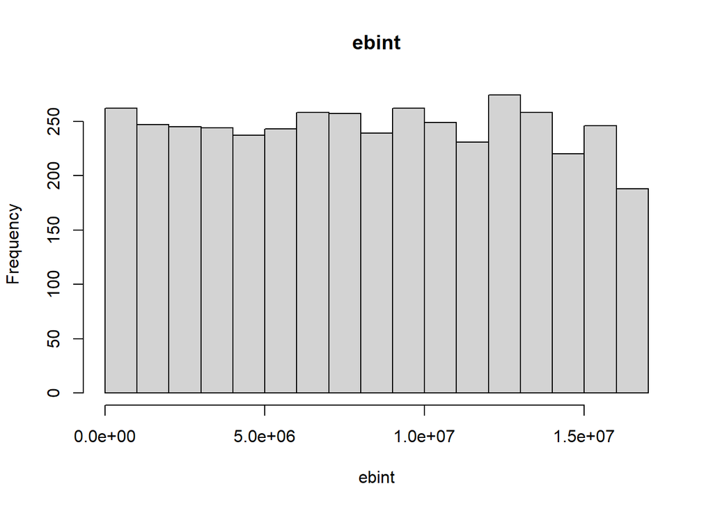

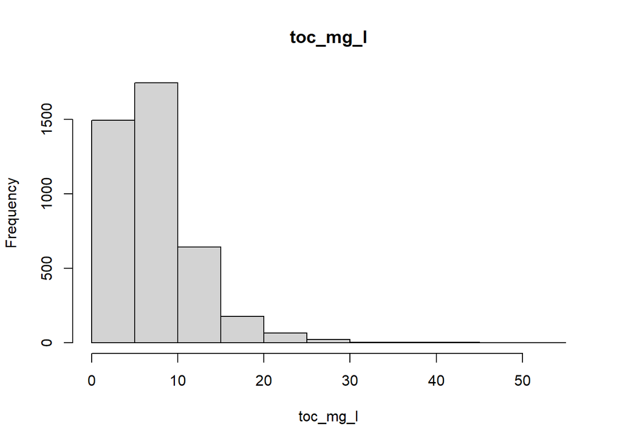

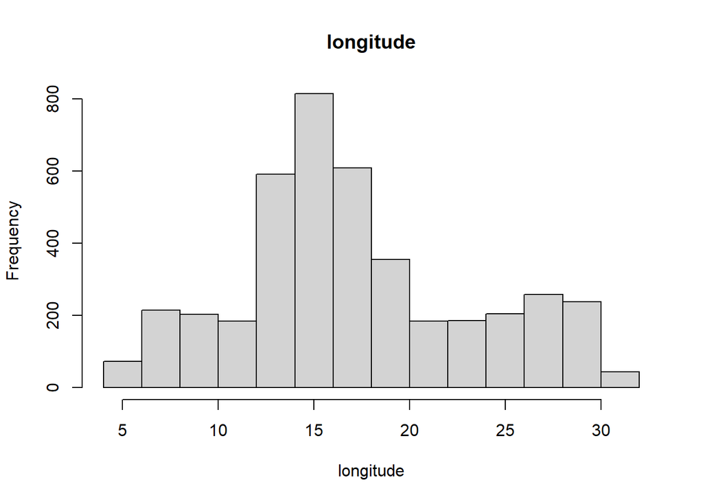

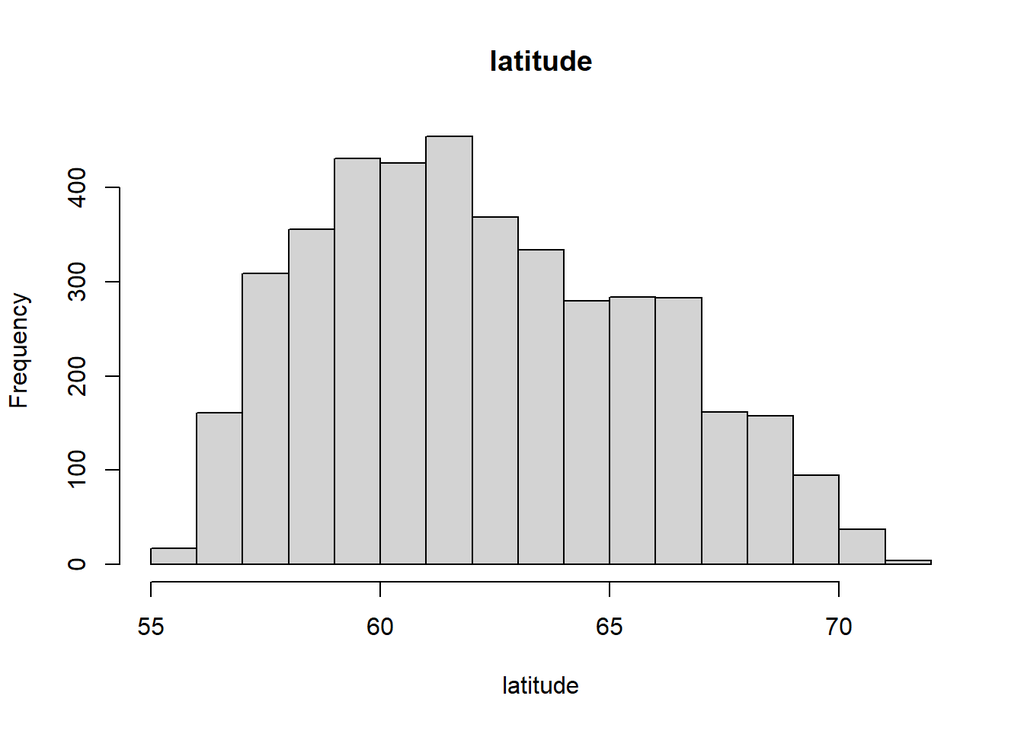

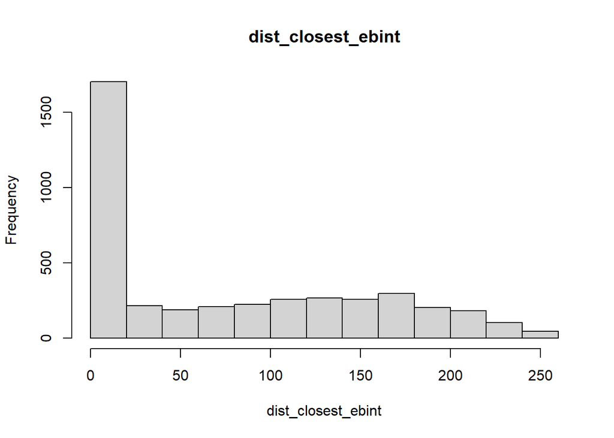

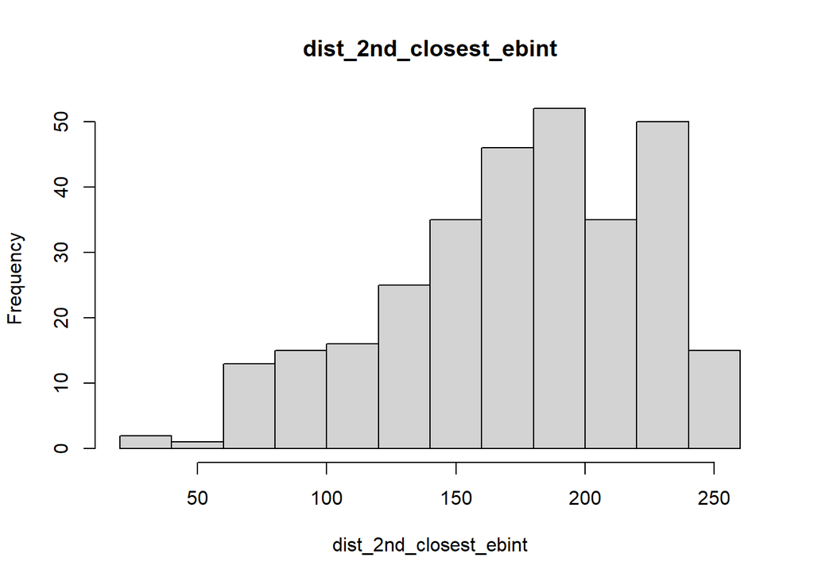

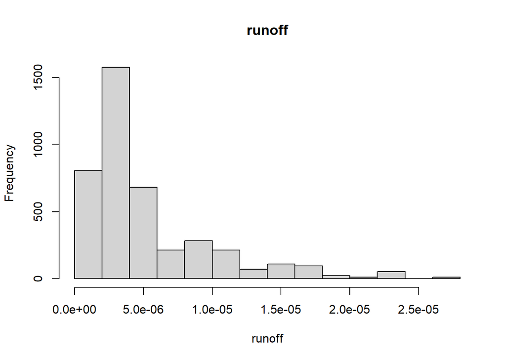

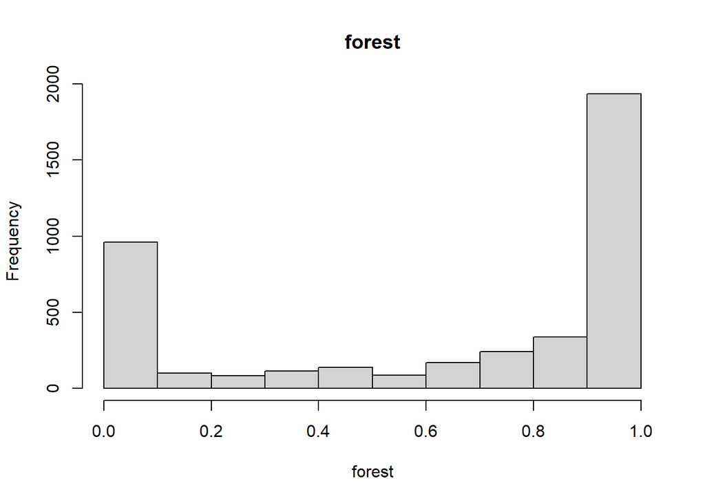

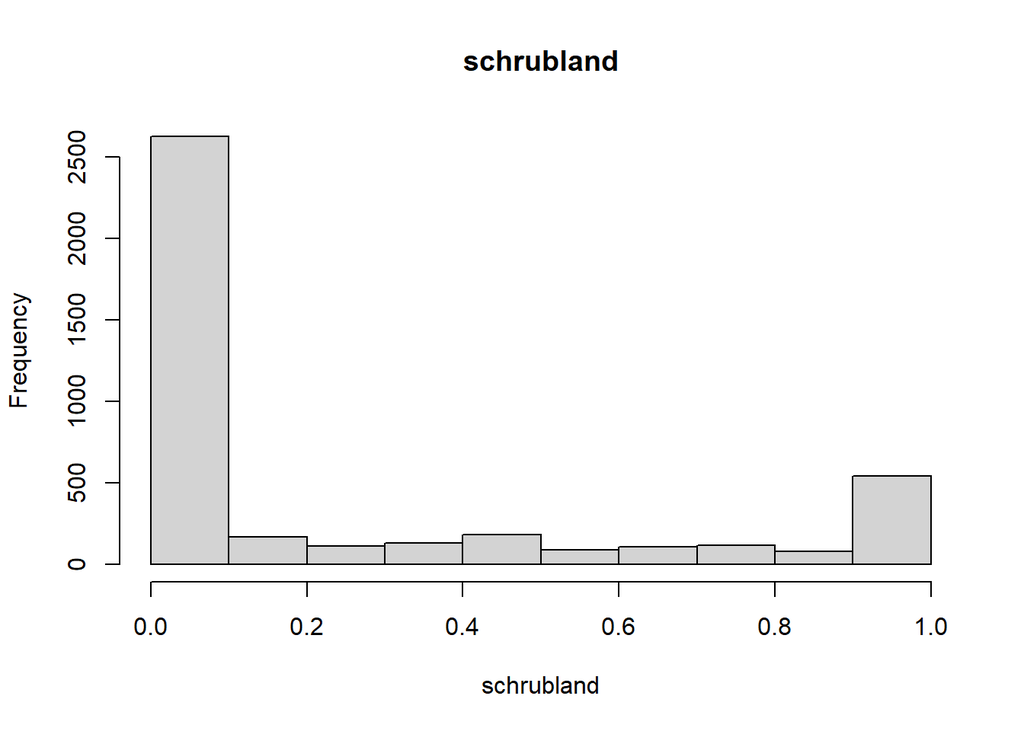

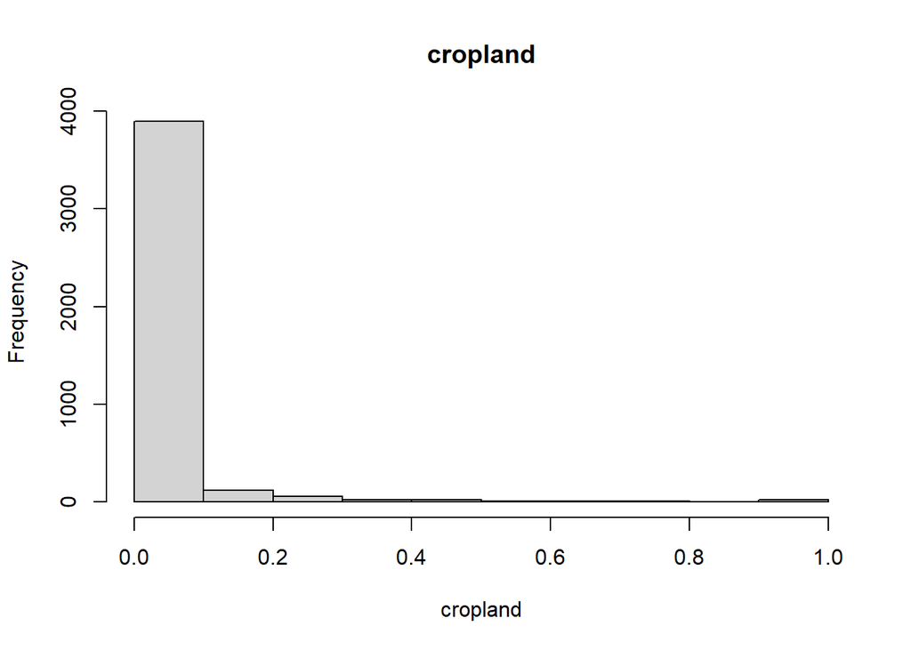

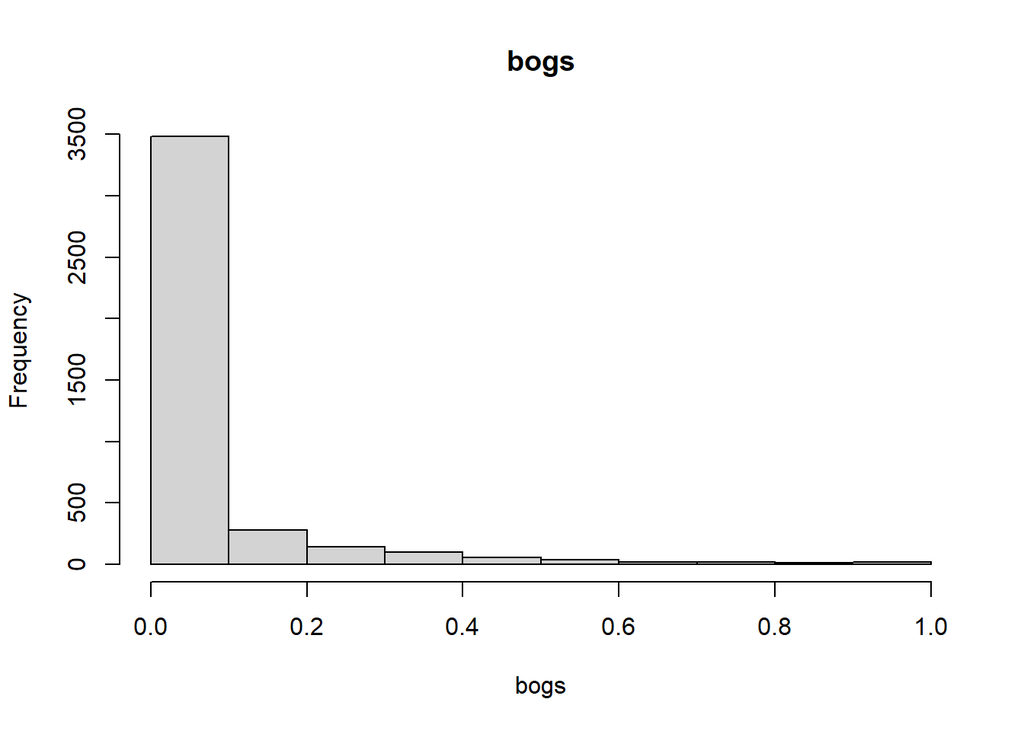

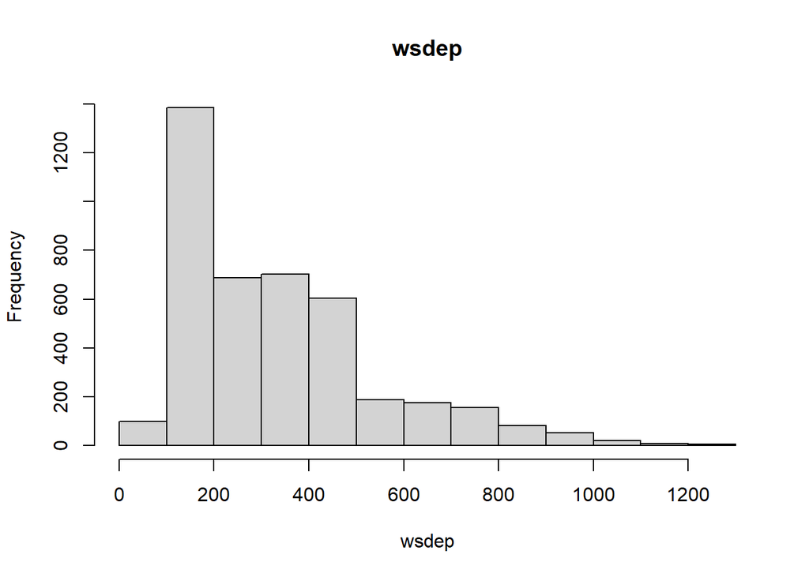

[8 more figures not shown]

```r
fen <- readRDS("fen.rds")

ghist <- function(df){
  df <- st_drop_geometry(df)
  i <- dim(df)[2]
  for(n in 1:i){
  hist(df[,n], main = names(df)[n], xlab = names(df)[n])
      }
}

ghist(fen)
```

```r
fen$sum <- with(fen, forest + bogs)
filter(fen, sum >= 1) %>% select(c("ebint","forest","bogs","sum"))
## Simple feature collection with 1643 features and 4 fields
## Geometry type: MULTIPOLYGON
## Dimension:     XY
## Bounding box:  xmin: 4.952522 ymin: 56.00598 xmax: 31.37528 ymax: 70.43777
## Geodetic CRS:  WGS 84 (with axis order normalized for visualization)
## First 10 features:
##    ebint    forest       bogs      sum                       geometry
## 1   4067 1.0000000 0.00000000 1.000000 MULTIPOLYGON (((16.07352 58...
## 2  24831 0.8478261 0.31437725 1.162203 MULTIPOLYGON (((30.00378 64...
## 3  25179 1.0000000 0.01718404 1.017184 MULTIPOLYGON (((15.39681 60...
## 4  28564 1.0000000 0.00000000 1.000000 MULTIPOLYGON (((28.99265 63...
## 5  36127 1.0000000 0.00000000 1.000000 MULTIPOLYGON (((15.18865 60...
## 6  39915 1.0000000 0.00000000 1.000000 MULTIPOLYGON (((13.22318 57...
## 7  47115 1.0000000 0.28980892 1.289809 MULTIPOLYGON (((20.38072 66...
## 8  61352 1.0000000 0.00000000 1.000000 MULTIPOLYGON (((22.55895 65...
## 9  61492 1.0000000 0.00000000 1.000000 MULTIPOLYGON (((16.18565 63...
## 10 75053 1.0000000 0.00000000 1.000000 MULTIPOLYGON (((27.85884 60...
```

# 2 Extract data for coastal drainage basins from 1899 to 2019

## 2.1 Catchment data

```r
wr.sf <- readRDS("wr.sf.rds")

sf_use_s2(FALSE)
wr.centroid <- st_centroid(wr.sf) %>% st_transform(st_crs(4326))
wr.sf$latitude <- st_coordinates(wr.centroid)[,2]

wr.sf.wgs84 <- st_transform(wr.sf, st_crs(4326))

lims <- c(0,20)
```

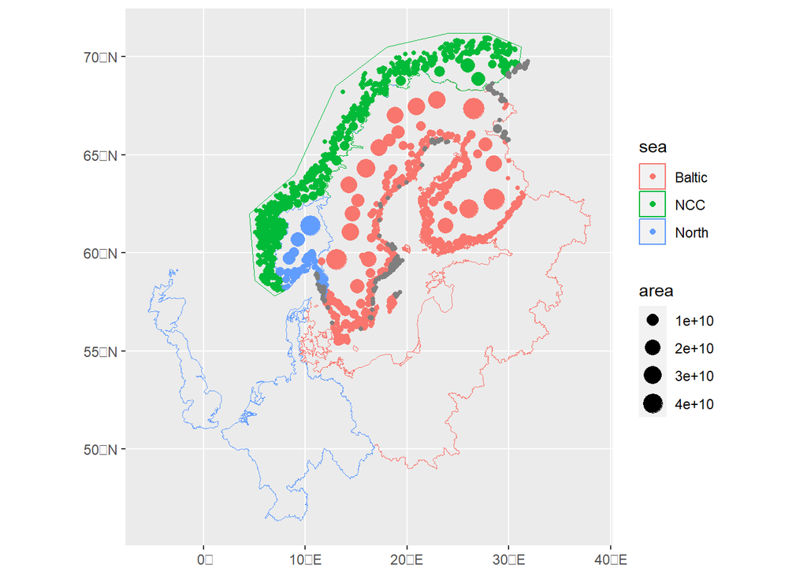

```r
basins <- st_read("basins_all_sea.shp") %>% st_cast("POLYGON")
## Reading layer `basins_all_sea' from data source
##   `C:\Users\raine\Documents\UiO\Green-blue\basins_all_sea.shp'
##   using driver `ESRI Shapefile'
## Simple feature collection with 254 features and 3 fields
## Geometry type: LINESTRING
## Dimension:     XY
## Bounding box:  xmin: -5.463723 ymin: 46.3282 xmax: 37.98894 ymax: 71.2
## Projected CRS: WGS 84 / Pseudo-Mercator
st_crs(basins) <- st_crs(4326)
basins$sea <- with(basins, ifelse(Poly %in% c(1:161), "Baltic",
                                  ifelse(Poly %in% c(162:253), "North",
                                    "NCC")))
wr.basins <- st_join(wr.centroid, basins, st_join = st_within)

ggplot()+ geom_sf(data = basins, aes(col = sea), fill = NA)+geom_sf(data = wr.basins, aes(col = sea, size = area))
```

```r
saveRDS(wr.basins, "wr.basins.rds")
```

```r
cod.table <- readxl::read_xlsx("Historical_COD.xlsx", sheet = "CODTable10km")
cod.sf <- st_as_sf(cod.table, coords = c("LonLinked","LatLinked"), crs = st_crs(4326))
cod.sf.sum <- cod.sf %>% group_by(Name, Year) %>% summarise(TOC = mean(as.numeric(COD), na.rm = T))

#match <- st_join(cod.sf.sum, wr.sf.wgs84, st_within)
#saveRDS(match,"match.swedish10.rds")

match <- readRDS("match.swedish10.rds")
merged.rivers <- match %>% select(c("Name","Year","TOC","gid"))

merged.rivers$decade <- ifelse(merged.rivers$Year %in% c(1894:1904), 1899,
                               ifelse(merged.rivers$Year %in% c(1904:1914), 1909,
                                ifelse(merged.rivers$Year %in% c(1914:1924), 1919,
                                ifelse(merged.rivers$Year %in% c(1924:1934), 1929,
                                ifelse(merged.rivers$Year %in% c(1924:1934), 1929,
                                ifelse(merged.rivers$Year %in% c(1934:1944), 1939,
                                ifelse(merged.rivers$Year %in% c(1944:1954), 1949,
                                ifelse(merged.rivers$Year %in% c(1954:1964), 1959,
                                ifelse(merged.rivers$Year %in% c(1964:1974), 1969,
                                ifelse(merged.rivers$Year %in% c(1974:1984), 1979,
                                ifelse(merged.rivers$Year %in% c(1984:1994), 1989,
                                ifelse(merged.rivers$Year %in% c(1994:2004), 1999,
                                ifelse(merged.rivers$Year %in% c(2004:2014), 2009,
                        2019)))))))))))))

ggplot()+geom_sf(data = filter(wr.sf.wgs84, gid %in% merged.rivers$gid))+geom_sf(data = merged.rivers, aes(color = Name))

saveRDS(merged.rivers, "merged.rivers10.rds")
```

```r
cod.table <- readxl::read_xlsx("Historical_COD.xlsx", sheet = "CODTable5km")
cod.sf <- st_as_sf(cod.table, coords = c("LonLinked","LatLinked"), crs = st_crs(4326))
cod.sf.sum <- cod.sf %>% group_by(Name, Year) %>% summarise(TOC = mean(as.numeric(COD), na.rm = T))

match <- st_join(cod.sf.sum, wr.sf.wgs84, st_within)
saveRDS(match,"match.swedish5.rds")

#match <- readRDS("match.swedish5.rds")
merged.rivers <- match %>% select(c("Name","Year","TOC","gid"))

merged.rivers$decade <- ifelse(merged.rivers$Year %in% c(1894:1904), 1899,
                               ifelse(merged.rivers$Year %in% c(1904:1914), 1909,
                                ifelse(merged.rivers$Year %in% c(1914:1924), 1919,
                                ifelse(merged.rivers$Year %in% c(1924:1934), 1929,
                                ifelse(merged.rivers$Year %in% c(1924:1934), 1929,
                                ifelse(merged.rivers$Year %in% c(1934:1944), 1939,
                                ifelse(merged.rivers$Year %in% c(1944:1954), 1949,
                                ifelse(merged.rivers$Year %in% c(1954:1964), 1959,
                                ifelse(merged.rivers$Year %in% c(1964:1974), 1969,
                                ifelse(merged.rivers$Year %in% c(1974:1984), 1979,
                                ifelse(merged.rivers$Year %in% c(1984:1994), 1989,
                                ifelse(merged.rivers$Year %in% c(1994:2004), 1999,
                                ifelse(merged.rivers$Year %in% c(2004:2014), 2009,
                        2019)))))))))))))

decade.toc <- merged.rivers %>% group_by(Name,decade) %>% summarise(TOC.decade = mean(as.numeric(TOC)))

merged.rivers <- merge(merged.rivers, st_drop_geometry(decade.toc), by = c("Name","decade"))

ggplot()+geom_sf(data = filter(wr.sf.wgs84, gid %in% merged.rivers$gid))+geom_sf(data = merged.rivers, aes(color = Name))

saveRDS(merged.rivers, "merged.rivers.rds")
```

## 2.2 HILDA

### 2.2.1 Extracting land-use

HILDA data are downloaded from https://www.wur.nl/en/research-results/chair-groups/environmental-sciences/laboratory-of-geo-information-science-and-remote-sensing/models/hilda/hilda-data-downloads.html

Hilda categories:

- 77: Water
- 66: Other land
- 55: Grass/schrubland
- 45: Forest, mixed
- 44: Forest, deciduous broad leaf
- 43: Forest: deciduous needle
- 42: Forest, evergreen borad leaf
- 41: Forest, evergreen needle
- 40: Forest, other
- 33: Pasture
- 22: Cropland
- 11: Urban

```r
hilda.raster <- "HILDA_plus_decadal.nc" %>% raster(band = 1)

hilda.1899 <- raster::extract(hilda.raster, wr.sf)

saveRDS(hilda.1899, "hilda.1899.wr.rds")

hilda.1899 <- readRDS("hilda.1899.wr.rds")
hilda.tab <- sapply(hilda.1899, function(x) tabulate(x,77))
hilda.tab.area <- hilda.tab*prod(res(hilda.raster))
catchment.area <- colSums(hilda.tab.area)
hilda.tab.prop <- sweep(hilda.tab.area,2,catchment.area, FUN = "/")
names(hilda.tab.prop) <- wr.sf$gid
saveRDS(hilda.tab.prop,"hilda.1899.tab.prop.Rdata")

forest <- colSums(hilda.tab.prop[c(40,41,42,43,44,45),]) %>% as.data.frame() %>% setNames("forest")
forest$gid <- wr.sf$gid
saveRDS(forest,"forest.1899.rds")
```

```r
hilda.raster <- "HILDA_plus_decadal.nc" %>% raster(band = 2)

hilda.1909 <- raster::extract(hilda.raster, wr.sf)

saveRDS(hilda.1909, "hilda.1909.wr.rds")

hilda.1909 <- readRDS("hilda.1909.wr.rds")
hilda.tab <- sapply(hilda.1909, function(x) tabulate(x,77))
hilda.tab.area <- hilda.tab*prod(res(hilda.raster))
catchment.area <- colSums(hilda.tab.area)
hilda.tab.prop <- sweep(hilda.tab.area,2,catchment.area, FUN = "/")
names(hilda.tab.prop) <- wr.sf$gid
saveRDS(hilda.tab.prop,"hilda.1909.tab.prop.Rdata")

forest <- colSums(hilda.tab.prop[c(40,41,42,43,44,45),]) %>% as.data.frame() %>% setNames("forest")
forest$gid <- wr.sf$gid
saveRDS(forest,"forest.1909.rds")
```

```r
hilda.raster <- "HILDA_plus_decadal.nc" %>% raster(band = 3)

hilda.1919 <- raster::extract(hilda.raster, wr.sf)

saveRDS(hilda.1919, "hilda.1919.wr.rds")

hilda.1919 <- readRDS("hilda.1919.wr.rds")
hilda.tab <- sapply(hilda.1919, function(x) tabulate(x,77))
hilda.tab.area <- hilda.tab*prod(res(hilda.raster))
catchment.area <- colSums(hilda.tab.area)
hilda.tab.prop <- sweep(hilda.tab.area,2,catchment.area, FUN = "/")
saveRDS(hilda.tab.prop,"hilda.1919.tab.prop.Rdata")

forest <- colSums(hilda.tab.prop[c(40,41,42,43,44,45),]) %>% as.data.frame() %>% setNames("forest")
forest$gid <- wr.sf$gid
saveRDS(forest,"forest.1919.rds")
```

```r
hilda.raster <- "HILDA_plus_decadal.nc" %>% raster(band = 4)

hilda.1929 <- raster::extract(hilda.raster, wr.sf)

saveRDS(hilda.1929, "hilda.1929.wr.rds")

hilda.1929 <- readRDS("hilda.1929.wr.rds")
hilda.tab <- sapply(hilda.1929, function(x) tabulate(x,77))
hilda.tab.area <- hilda.tab*prod(res(hilda.raster))
catchment.area <- colSums(hilda.tab.area)
hilda.tab.prop <- sweep(hilda.tab.area,2,catchment.area, FUN = "/")
saveRDS(hilda.tab.prop,"hilda.1929.tab.prop.Rdata")

forest <- colSums(hilda.tab.prop[c(40,41,42,43,44,45),]) %>% as.data.frame() %>% setNames("forest")
forest$gid <- wr.sf$gid

saveRDS(forest,"forest.1929.rds")
```

```r
hilda.raster <- "HILDA_plus_decadal.nc" %>% raster(band = 5)

hilda.1939 <- raster::extract(hilda.raster, wr.sf)

saveRDS(hilda.1939, "hilda.1939.wr.rds")

hilda.1939 <- readRDS("hilda.1939.wr.rds")
hilda.tab <- sapply(hilda.1939, function(x) tabulate(x,77))
hilda.tab.area <- hilda.tab*prod(res(hilda.raster))
catchment.area <- colSums(hilda.tab.area)
hilda.tab.prop <- sweep(hilda.tab.area,2,catchment.area, FUN = "/")
saveRDS(hilda.tab.prop,"hilda.1939.tab.prop.Rdata")

forest <- colSums(hilda.tab.prop[c(40,41,42,43,44,45),]) %>% as.data.frame() %>% setNames("forest")
forest$gid <- wr.sf$gid
saveRDS(forest,"forest.1939.rds")
```

```r
hilda.raster <- "HILDA_plus_decadal.nc" %>% raster(band = 6)

hilda.1949 <- raster::extract(hilda.raster, wr.sf)

saveRDS(hilda.1949, "hilda.1949.wr.rds")

hilda.1949 <- readRDS("hilda.1949.wr.rds")
hilda.tab <- sapply(hilda.1949, function(x) tabulate(x,77))
hilda.tab.area <- hilda.tab*prod(res(hilda.raster))
catchment.area <- colSums(hilda.tab.area)
hilda.tab.prop <- sweep(hilda.tab.area,2,catchment.area, FUN = "/")
names(hilda.tab.prop) <- wr.sf$gid
saveRDS(hilda.tab.prop,"hilda.1949.tab.prop.Rdata")

forest <- colSums(hilda.tab.prop[c(40,41,42,43,44,45),]) %>% as.data.frame() %>% setNames("forest")
forest$gid <- wr.sf$gid
saveRDS(forest,"forest.1949.rds")
```

```r
hilda.raster <- "HILDA_plus_decadal.nc" %>% raster(band = 7)

hilda.1959 <- raster::extract(hilda.raster, wr.sf)

saveRDS(hilda.1959, "hilda.1959.wr.rds")

hilda.1959 <- readRDS("hilda.1959.wr.rds")
hilda.tab <- sapply(hilda.1959, function(x) tabulate(x,77))
hilda.tab.area <- hilda.tab*prod(res(hilda.raster))
catchment.area <- colSums(hilda.tab.area)
hilda.tab.prop <- sweep(hilda.tab.area,2,catchment.area, FUN = "/")
names(hilda.tab.prop) <- wr.sf$gid
saveRDS(hilda.tab.prop,"hilda.1959.tab.prop.Rdata")

forest <- colSums(hilda.tab.prop[c(40,41,42,43,44,45),]) %>% as.data.frame() %>% setNames("forest")
forest$gid <- wr.sf$gid
saveRDS(forest,"forest.1959.rds")
```

```r
hilda.raster <- "HILDA_plus_decadal.nc" %>% raster(band = 8)

hilda.1969 <- raster::extract(hilda.raster, wr.sf)

saveRDS(hilda.1969, "hilda.1969.wr.rds")

hilda.1969 <- readRDS("hilda.1969.wr.rds")
hilda.tab <- sapply(hilda.1969, function(x) tabulate(x,77))
hilda.tab.area <- hilda.tab*prod(res(hilda.raster))
catchment.area <- colSums(hilda.tab.area)
hilda.tab.prop <- sweep(hilda.tab.area,2,catchment.area, FUN = "/")
names(hilda.tab.prop) <- wr.sf$gid
saveRDS(hilda.tab.prop,"hilda.1969.tab.prop.Rdata")

forest <- colSums(hilda.tab.prop[c(40,41,42,43,44,45),]) %>% as.data.frame() %>% setNames("forest")
forest$gid <- wr.sf$gid

saveRDS(forest,"forest.1969.rds")
```

```r
hilda.raster <- "HILDA_plus_decadal.nc" %>% raster(band = 9)

hilda.1979 <- raster::extract(hilda.raster, wr.sf)

saveRDS(hilda.1979, "hilda.1979.wr.rds")

hilda.1979 <- readRDS("hilda.1979.wr.rds")
hilda.tab <- sapply(hilda.1979, function(x) tabulate(x,77))
hilda.tab.area <- hilda.tab*prod(res(hilda.raster))
catchment.area <- colSums(hilda.tab.area)
hilda.tab.prop <- sweep(hilda.tab.area,2,catchment.area, FUN = "/")
names(hilda.tab.prop) <- wr.sf$gid
saveRDS(hilda.tab.prop,"hilda.1979.tab.prop.Rdata")

forest <- colSums(hilda.tab.prop[c(40,41,42,43,44,45),]) %>% as.data.frame() %>% setNames("forest")
forest$gid <- wr.sf$gid
saveRDS(forest,"forest.1979.rds")
```

```r
hilda.raster <- "HILDA_plus_decadal.nc" %>% raster(band = 10)

hilda.1989 <- raster::extract(hilda.raster, wr.sf)

saveRDS(hilda.1989, "hilda.1989.wr.rds")


hilda.1989 <- readRDS("hilda.1989.wr.rds")
hilda.tab <- sapply(hilda.1989, function(x) tabulate(x,77))
hilda.tab.area <- hilda.tab*prod(res(hilda.raster))
catchment.area <- colSums(hilda.tab.area)
hilda.tab.prop <- sweep(hilda.tab.area,2,catchment.area, FUN = "/")
names(hilda.tab.prop) <- wr.sf$gid
saveRDS(hilda.tab.prop,"hilda.1989.tab.prop.Rdata")

forest <- colSums(hilda.tab.prop[c(40,41,42,43,44,45),]) %>% as.data.frame() %>% setNames("forest")
forest$gid <- wr.sf$gid
saveRDS(forest,"forest.1989.rds")
```

```r
hilda.raster <- "HILDA_plus_decadal.nc" %>% raster(band = 11)

hilda.1999 <- raster::extract(hilda.raster, wr.sf)

saveRDS(hilda.1999, "hilda.1999.wr.rds")

hilda.1999 <- readRDS("hilda.1999.wr.rds")
hilda.tab <- sapply(hilda.1999, function(x) tabulate(x,77))
hilda.tab.area <- hilda.tab*prod(res(hilda.raster))
catchment.area <- colSums(hilda.tab.area)
hilda.tab.prop <- sweep(hilda.tab.area,2,catchment.area, FUN = "/")
names(hilda.tab.prop) <- wr.sf$gid
saveRDS(hilda.tab.prop,"hilda.1999.tab.prop.Rdata")

forest <- colSums(hilda.tab.prop[c(40,41,42,43,44,45),]) %>% as.data.frame() %>% setNames("forest")
forest$gid <- wr.sf$gid
saveRDS(forest,"forest.1999.rds")
```

```r
hilda.raster <- "HILDA_plus_decadal.nc" %>% raster(band = 12)

hilda.2009 <- raster::extract(hilda.raster, wr.sf)

saveRDS(hilda.2009, "hilda.2009.wr.rds")

hilda.2009 <- readRDS("hilda.2009.wr.rds")
hilda.tab <- sapply(hilda.2009, function(x) tabulate(x,77))
hilda.tab.area <- hilda.tab*prod(res(hilda.raster))
catchment.area <- colSums(hilda.tab.area)
hilda.tab.prop <- sweep(hilda.tab.area,2,catchment.area, FUN = "/")
names(hilda.tab.prop) <- wr.sf$gid
saveRDS(hilda.tab.prop,"hilda.2009.tab.prop.Rdata")

forest <- colSums(hilda.tab.prop[c(40,41,42,43,44,45),]) %>% as.data.frame() %>% setNames("forest")
forest$gid <- wr.sf$gid

saveRDS(forest,"forest.2009.rds")
```

```r
hilda.raster <- "HILDA_plus_decadal.nc" %>% raster(band = 13)

hilda.2019 <- raster::extract(hilda.raster, wr.sf)

saveRDS(hilda.2019, "hilda.2019.wr.rds")

hilda.2019 <- readRDS("hilda.2019.wr.rds")
hilda.tab <- sapply(hilda.2019, function(x) tabulate(x,77))
hilda.tab.area <- hilda.tab*prod(res(hilda.raster))
catchment.area <- colSums(hilda.tab.area)
hilda.tab.prop <- sweep(hilda.tab.area,2,catchment.area, FUN = "/")
names(hilda.tab.prop) <- wr.sf$gid
saveRDS(hilda.tab.prop,"hilda.2019.tab.prop.Rdata")

forest <- colSums(hilda.tab.prop[c(40,41,42,43,44,45),]) %>% as.data.frame() %>% setNames("forest")
forest$gid <- wr.sf$gid
saveRDS(forest,"forest.2019.rds")
```

### 2.2.2 Evolution forest

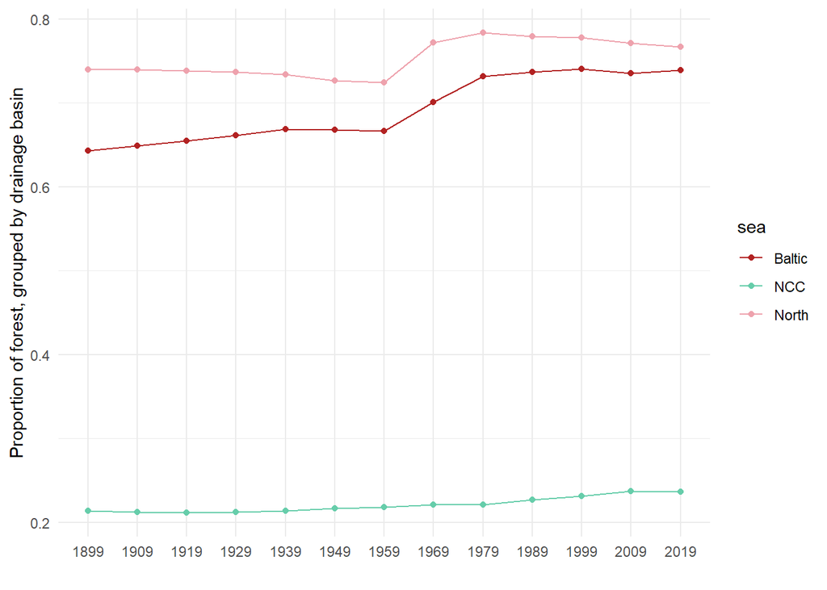

```r
forest.1899 <- readRDS("forest.1899.rds") %>% mutate(year = "1899")
forest.1909 <- readRDS("forest.1909.rds") %>% mutate(year = "1909")
forest.1919 <- readRDS("forest.1919.rds") %>% mutate(year = "1919")
forest.1929 <- readRDS("forest.1929.rds") %>% mutate(year = "1929")
forest.1939 <- readRDS("forest.1939.rds") %>% mutate(year = "1939")
forest.1949 <- readRDS("forest.1949.rds") %>% mutate(year = "1949")
forest.1959 <- readRDS("forest.1959.rds") %>% mutate(year = "1959")
forest.1969 <- readRDS("forest.1969.rds") %>% mutate(year = "1969")
forest.1979 <- readRDS("forest.1979.rds") %>% mutate(year = "1979")
forest.1989 <- readRDS("forest.1989.rds") %>% mutate(year = "1989")
forest.1999 <- readRDS("forest.1999.rds") %>% mutate(year = "1999")
forest.2009 <- readRDS("forest.2009.rds") %>% mutate(year = "2009")
forest.2019 <- readRDS("forest.2019.rds") %>% mutate(year = "2019")

wr.basins <- readRDS("wr.basins.rds")

all.forest <- forest.1899 %>% rbind(forest.1909) %>% rbind(forest.1919) %>% rbind(forest.1929) %>% rbind(forest.1939) %>% rbind(forest.1949) %>% rbind(forest.1959) %>% rbind(forest.1969) %>% rbind(forest.1979) %>% rbind(forest.1989) %>% rbind(forest.1999) %>% rbind(forest.2009) %>% rbind(forest.2019) %>% merge(st_drop_geometry(wr.basins), by = "gid") %>% group_by(sea,year) %>% summarise(forest = mean(forest, na.rm = T)) %>% filter(!is.na(sea)) %>% setNames(c("sea","year","prop")) %>% mutate(category = "forest")

ggplot(data = filter(all.forest, !is.na(sea)) , aes(x = year, y = prop, col = sea))+geom_point()+
         geom_line(aes(group = sea))+
         scale_color_manual(values = c("firebrick","mediumaquamarine", "lightpink2"))+
         labs(x = "", y = "Proportion of forest, grouped by drainage basin")+
         theme_minimal()
```

### 2.2.3 Evolution schrubland

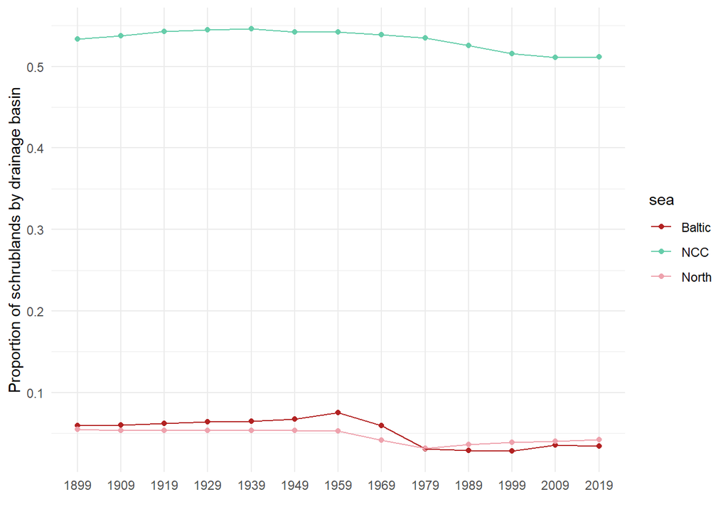

```r
schrubland.1899 <- readRDS("schrubland.1899.rds") %>% mutate(year = "1899")
schrubland.1909 <- readRDS("schrubland.1909.rds") %>% mutate(year = "1909")
schrubland.1919 <- readRDS("schrubland.1919.rds") %>% mutate(year = "1919")
schrubland.1929 <- readRDS("schrubland.1929.rds") %>% mutate(year = "1929")
schrubland.1939 <- readRDS("schrubland.1939.rds") %>% mutate(year = "1939")
schrubland.1949 <- readRDS("schrubland.1949.rds") %>% mutate(year = "1949")
schrubland.1959 <- readRDS("schrubland.1959.rds") %>% mutate(year = "1959")
schrubland.1969 <- readRDS("schrubland.1969.rds") %>% mutate(year = "1969")
schrubland.1979 <- readRDS("schrubland.1979.rds") %>% mutate(year = "1979")
schrubland.1989 <- readRDS("schrubland.1989.rds") %>% mutate(year = "1989")
schrubland.1999 <- readRDS("schrubland.1999.rds") %>% mutate(year = "1999")
schrubland.2009 <- readRDS("schrubland.2009.rds") %>% mutate(year = "2009")
schrubland.2019 <- readRDS("schrubland.2019.rds") %>% mutate(year = "2019")

wr.basins <- readRDS("wr.basins.rds")

all.schrubland <- schrubland.1899 %>% rbind(schrubland.1909) %>% rbind(schrubland.1919) %>% rbind(schrubland.1929) %>% rbind(schrubland.1939) %>% rbind(schrubland.1949) %>% rbind(schrubland.1959) %>% rbind(schrubland.1969) %>% rbind(schrubland.1979) %>% rbind(schrubland.1989) %>% rbind(schrubland.1999) %>% rbind(schrubland.2009) %>% rbind(schrubland.2019) %>% merge(st_drop_geometry(wr.basins), by = "gid") %>% group_by(sea,year) %>% summarise(schrubland = mean(schrubland, na.rm = T)) %>% filter(!is.na(sea)) %>% setNames(c("sea","year","prop")) %>% mutate(category = "shrubland")



ggplot(all.schrubland, aes(x = year, y = prop, col = sea))+geom_point()+geom_line(aes(group = sea))+
  scale_color_manual(values = c("firebrick","mediumaquamarine", "lightpink2"))+
  labs(x="", y = "Proportion of schrublands by drainage basin")+theme_minimal()
```

### 2.2.4 Evolution cropland

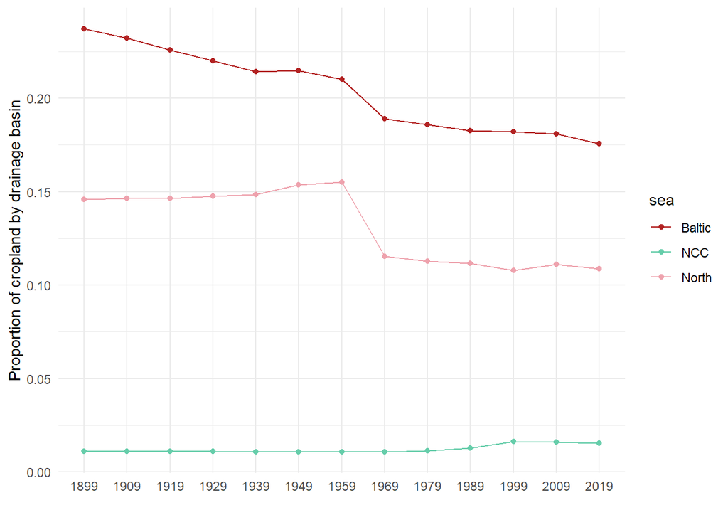

```r
cropland.1899 <- readRDS("cropland.1899.rds") %>% mutate(year = "1899")
cropland.1909 <- readRDS("cropland.1909.rds") %>% mutate(year = "1909")
cropland.1919 <- readRDS("cropland.1919.rds") %>% mutate(year = "1919")
cropland.1929 <- readRDS("cropland.1929.rds") %>% mutate(year = "1929")
cropland.1939 <- readRDS("cropland.1939.rds") %>% mutate(year = "1939")
cropland.1949 <- readRDS("cropland.1949.rds") %>% mutate(year = "1949")
cropland.1959 <- readRDS("cropland.1959.rds") %>% mutate(year = "1959")
cropland.1969 <- readRDS("cropland.1969.rds") %>% mutate(year = "1969")
cropland.1979 <- readRDS("cropland.1979.rds") %>% mutate(year = "1979")
cropland.1989 <- readRDS("cropland.1989.rds") %>% mutate(year = "1989")
cropland.1999 <- readRDS("cropland.1999.rds") %>% mutate(year = "1999")
cropland.2009 <- readRDS("cropland.2009.rds") %>% mutate(year = "2009")
cropland.2019 <- readRDS("cropland.2019.rds") %>% mutate(year = "2019")

wr.basins <- readRDS("wr.basins.rds")

all.cropland <- cropland.1899 %>% rbind(cropland.1909) %>% rbind(cropland.1919) %>% rbind(cropland.1929) %>% rbind(cropland.1939) %>% rbind(cropland.1949) %>% rbind(cropland.1959) %>% rbind(cropland.1969) %>% rbind(cropland.1979) %>% rbind(cropland.1989) %>% rbind(cropland.1999) %>% rbind(cropland.2009) %>% rbind(cropland.2019) %>% merge(st_drop_geometry(wr.basins), by = "gid") %>% group_by(sea,year) %>% summarise(cropland = mean(cropland, na.rm = T)) %>% filter(!is.na(sea)) %>% setNames(c("sea","year","prop")) %>% mutate(category = "cropland")



ggplot(all.cropland, aes(x = year, y = prop, col = sea))+geom_point()+geom_line(aes(group = sea))+
  scale_color_manual(values = c("firebrick","mediumaquamarine", "lightpink2"))+
  labs(x = "", y = "Proportion of cropland by drainage basin") +
  theme_minimal()
```

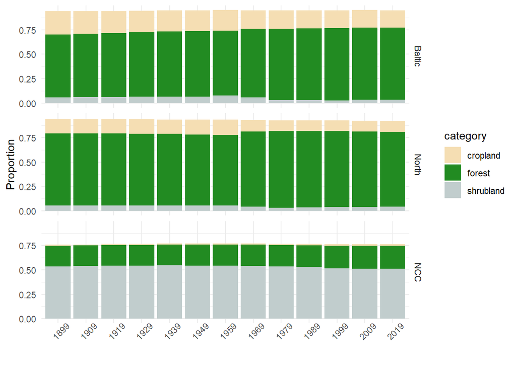

```r
hilda <- all.forest %>% rbind(all.schrubland) %>% rbind(all.cropland)
hilda$sea <- factor(hilda$sea, levels = c("Baltic","North","NCC"))

ggplot(hilda)+geom_bar(aes(x = year, y = prop, fill = category), position = "stack", stat = "identity")+
  facet_grid(rows = vars(sea))+
  labs(x = "", y = "Proportion")+
  scale_fill_manual(values = c("wheat", "forestgreen","azure3"))+
  theme_minimal()+
  theme(legend.position = "right", axis.text.x =element_text(angle = 45))
```

### 2.2.5 Compare bogs/forest

Bogs extracted from Corine Land Cover 2006

```r
wr.bogs <- readRDS("bogs.wr.rds")

forest.1899 <- wr.sf.wgs84 %>% merge(readRDS("forest.1899.rds"), by = "gid") %>% merge(wr.bogs, by = "gid") %>% mutate(sum = bogs + forest)

ggplot(filter(forest.1899, sum >= 1))+geom_sf(aes(fill = sum, col = sum))+
  borders(database = "world", regions = c("Norway", "Sweden","Finland"))+
  scale_fill_viridis_c(limits = c(1,1.3), aesthetics = c("colour","fill"))+
  ylim(55,72)+xlim(4,33)+
  labs(title = "1899", subtitle = paste(round(sum(subset(forest.1899, sum >= 1)$area/sum(wr.sf.wgs84$area))*100, 2),"%"," "))+
  theme_void()

forest.1909 <- wr.sf.wgs84 %>% merge(readRDS("forest.1909.rds"), by = "gid") %>% merge(wr.bogs, by = "gid") %>% mutate(sum = bogs + forest)

ggplot(filter(forest.1909, sum >= 1))+geom_sf(aes(fill = sum, col = sum))+
  borders(database = "world", regions = c("Norway", "Sweden","Finland"))+
  scale_fill_viridis_c(limits = c(1,1.3), aesthetics = c("colour","fill"))+
  ylim(55,72)+xlim(4,33)+
  labs(title = "1909", subtitle = paste(round(sum(subset(forest.1909, sum >= 1)$area/sum(wr.sf.wgs84$area))*100, 2),"%"," "))+
  theme_void()

forest.1919 <- wr.sf.wgs84 %>% merge(readRDS("forest.1919.rds"), by = "gid") %>% merge(wr.bogs, by = "gid") %>% mutate(sum = bogs + forest)

ggplot(filter(forest.1919, sum >= 1))+geom_sf(aes(fill = sum, col = sum))+
  borders(database = "world", regions = c("Norway", "Sweden","Finland"))+
  scale_fill_viridis_c(limits = c(1,1.3), aesthetics = c("colour","fill"))+
   ylim(55,72)+xlim(4,33)+
  labs(title = "1919", subtitle = paste(round(sum(subset(forest.1919, sum >= 1)$area/sum(wr.sf.wgs84$area))*100, 2),"%"," "))+
  theme_void()

forest.1929 <- wr.sf.wgs84 %>% merge(readRDS("forest.1929.rds"), by = "gid") %>% merge(wr.bogs, by = "gid") %>% mutate(sum = bogs + forest)

ggplot(filter(forest.1929, sum >= 1))+geom_sf(aes(fill = sum, col = sum))+
  borders(database = "world", regions = c("Norway", "Sweden","Finland"))+
  scale_fill_viridis_c(limits = c(1,1.3), aesthetics = c("colour","fill"))+
  ylim(55,72)+xlim(4,33)+
  labs(title = "1929", subtitle = paste(round(sum(subset(forest.1929, sum >= 1)$area/sum(wr.sf.wgs84$area))*100, 2),"%"," "))+
  theme_void()

forest.1939 <- wr.sf.wgs84 %>% merge(readRDS("forest.1939.rds"), by = "gid") %>% merge(wr.bogs, by = "gid") %>% mutate(sum = bogs + forest)

ggplot(filter(forest.1939, sum >= 1))+geom_sf(aes(fill = sum, col = sum))+
  borders(database = "world", regions = c("Norway", "Sweden","Finland"))+
  scale_fill_viridis_c(limits = c(1,1.3), aesthetics = c("colour","fill"))+
    ylim(55,72)+xlim(4,33)+
  labs(title = "1939", subtitle = paste(round(sum(subset(forest.1939, sum >= 1)$area/sum(wr.sf.wgs84$area))*100, 2),"%"," "))+
  theme_void()

forest.1949 <- wr.sf.wgs84 %>% merge(readRDS("forest.1949.rds"), by = "gid") %>% merge(wr.bogs, by = "gid") %>% mutate(sum = bogs + forest)

ggplot(filter(forest.1949, sum >= 1))+geom_sf(aes(fill = sum, col = sum))+
  borders(database = "world", regions = c("Norway", "Sweden","Finland"))+
  scale_fill_viridis_c(limits = c(1,1.3), aesthetics = c("colour","fill"))+
  ylim(55,72)+xlim(4,33)+
  labs(title = "1949", subtitle = paste(round(sum(subset(forest.1949, sum >= 1)$area/sum(wr.sf.wgs84$area))*100, 2),"%"," "))+
  theme_void()

forest.1959 <- wr.sf.wgs84 %>% merge(readRDS("forest.1959.rds"), by = "gid") %>% merge(wr.bogs, by = "gid") %>% mutate(sum = bogs + forest)

ggplot(filter(forest.1959, sum >= 1))+geom_sf(aes(fill = sum, col = sum))+
  borders(database = "world", regions = c("Norway", "Sweden","Finland"))+
  scale_fill_viridis_c(limits = c(1,1.3), aesthetics = c("colour","fill"))+
  ylim(55,72)+xlim(4,33)+
  labs(title = "1959", subtitle = paste(round(sum(subset(forest.1959, sum >= 1)$area/sum(wr.sf.wgs84$area))*100, 2),"%"," "))+
  theme_void()

forest.1969 <- wr.sf.wgs84 %>% merge(readRDS("forest.1969.rds"), by = "gid") %>% merge(wr.bogs, by = "gid") %>% mutate(sum = bogs + forest)

ggplot(filter(forest.1969, sum >= 1))+geom_sf(aes(fill = sum, col = sum))+
  borders(database = "world", regions = c("Norway", "Sweden","Finland"))+
  scale_fill_viridis_c(limits = c(1,1.3), aesthetics = c("colour","fill"))+
  ylim(55,72)+xlim(4,33)+
  labs(title = "1969", subtitle = paste(round(sum(subset(forest.1969, sum >= 1)$area/sum(wr.sf.wgs84$area))*100, 2),"%"," "))+
  theme_void()

forest.1979 <- wr.sf.wgs84 %>% merge(readRDS("forest.1979.rds"), by = "gid") %>% merge(wr.bogs, by = "gid") %>% mutate(sum = bogs + forest)

ggplot(filter(forest.1979, sum >= 1))+geom_sf(aes(fill = sum, col = sum))+
  borders(database = "world", regions = c("Norway", "Sweden","Finland"))+
  scale_fill_viridis_c(limits = c(1,1.3), aesthetics = c("colour","fill"))+
  ylim(55,72)+xlim(4,33)+
  labs(title = "1979", subtitle = paste(round(sum(subset(forest.1979, sum >= 1)$area/sum(wr.sf.wgs84$area))*100, 2),"%"," "))+
  theme_void()

forest.1989 <- wr.sf.wgs84 %>% merge(readRDS("forest.1989.rds"), by = "gid") %>% merge(wr.bogs, by = "gid") %>% mutate(sum = bogs + forest)

ggplot(filter(forest.1989, sum >= 1))+geom_sf(aes(fill = sum, col = sum))+
  borders(database = "world", regions = c("Norway", "Sweden","Finland"))+
  scale_fill_viridis_c(limits = c(1,1.3), aesthetics = c("colour","fill"))+
  ylim(55,72)+xlim(4,33)+
  labs(title = "1989", subtitle = paste(round(sum(subset(forest.1989, sum >= 1)$area/sum(wr.sf.wgs84$area))*100, 2),"%"," "))+
  theme_void()

forest.1999 <- wr.sf.wgs84 %>% merge(readRDS("forest.1999.rds"), by = "gid") %>% merge(wr.bogs, by = "gid") %>% mutate(sum = bogs + forest)

ggplot(filter(forest.1999, sum >= 1))+geom_sf(aes(fill = sum, col = sum))+
  borders(database = "world", regions = c("Norway", "Sweden","Finland"))+
  scale_fill_viridis_c(limits = c(1,1.3), aesthetics = c("colour","fill"))+
  ylim(55,72)+xlim(4,33)+
  labs(title = "1999", subtitle = paste(round(sum(subset(forest.1999, sum >= 1)$area/sum(wr.sf.wgs84$area))*100, 2),"%"," "))+
  theme_void()

forest.2009 <- wr.sf.wgs84 %>% merge(readRDS("forest.2009.rds"), by = "gid") %>% merge(wr.bogs, by = "gid") %>% mutate(sum = bogs + forest)

ggplot(filter(forest.2009, sum >= 1))+geom_sf(aes(fill = sum, col = sum))+
  borders(database = "world", regions = c("Norway", "Sweden","Finland"))+
  scale_fill_viridis_c(limits = c(1,1.3), aesthetics = c("colour","fill"))+
  ylim(55,72)+xlim(4,33)+
  labs(title = "2009", subtitle = paste(round(sum(subset(forest.2009, sum >= 1)$area/sum(wr.sf.wgs84$area))*100, 2),"%"," "))+
  theme_void()

forest.2019 <- wr.sf.wgs84 %>% merge(readRDS("forest.2019.rds"), by = "gid") %>% merge(wr.bogs, by = "gid") %>% mutate(sum = bogs + forest)

ggplot(filter(forest.2019, sum >= 1))+geom_sf(aes(fill = sum, col = sum))+
  borders(database = "world", regions = c("Norway", "Sweden","Finland"))+
  scale_fill_viridis_c(limits = c(1,1.3), aesthetics = c("colour","fill"))+
  ylim(55,72)+xlim(4,33)+
  labs(title = "2019", subtitle = paste(round(sum(subset(forest.2019, sum >= 1)$area/sum(wr.sf.wgs84$area))*100, 2),"%"," "))+
  theme_void()
```

[output not shown]

## 2.3 Sdep

### 2.3.1 Extracting Sdep

```r
wr.sf <- readRDS("wr.sf.rds")
```

```r
dryso2 <- raster::stack("Sdep/dryso2_aero_NorESM1-ME_historical_r1i1p1_185001-200512.nc", bands = c(409:660)) %>% mean() # mean 1894-1904
dryso4 <- raster::stack("Sdep/dryso4_aero_NorESM1-ME_historical_r1i1p1_185001-200512.nc", bands = c(409:660)) %>% mean()
wetso2 <- raster::stack("Sdep/wetso2_aero_NorESM1-ME_historical_r1i1p1_185001-200512.nc", bands = c(409:660)) %>% mean()
wetso4 <- raster::stack("Sdep/wetso4_aero_NorESM1-ME_historical_r1i1p1_185001-200512.nc", bands = c(409:660)) %>% mean()

dryso2.df <- extract(dryso2, wr.sf, sp = T, df = T, na.rm = T, fun = mean)
names(dryso2.df) <- c("gid","area","dso2")
dryso4.df <- extract(dryso4, wr.sf, sp = T, df = T, na.rm = T, fun = mean)
names(dryso4.df) <- c("gid","area","dso4")
wetso2.df <- extract(wetso2, wr.sf, sp = T, df = T, na.rm = T, fun = mean)
names(wetso2.df) <- c("gid","area","wso2")
wetso4.df <- extract(wetso4, wr.sf, sp = T, df = T, na.rm = T, fun = mean)
names(wetso4.df) <- c("gid","area","wso4")

sdep.df <- merge(dryso2.df, dryso4.df, by = "gid") %>% merge(wetso2.df, by = "gid") %>% merge(wetso4.df, by = c("gid","area"))
sdep.df$tsdep <- rowSums(sdep.df@data[,c(3:6)])

saveRDS(sdep.df, "sdep.df.1899.rds")
```

```r
dryso2 <- raster::stack("Sdep/dryso2_aero_NorESM1-ME_historical_r1i1p1_185001-200512.nc", bands = c(661:780)) %>% mean()
dryso4 <- raster::stack("Sdep/dryso4_aero_NorESM1-ME_historical_r1i1p1_185001-200512.nc", bands = c(661:780)) %>% mean()
wetso2 <- raster::stack("Sdep/wetso2_aero_NorESM1-ME_historical_r1i1p1_185001-200512.nc", bands = c(661:780)) %>% mean()
wetso4 <- raster::stack("Sdep/wetso4_aero_NorESM1-ME_historical_r1i1p1_185001-200512.nc", bands = c(661:780)) %>% mean()

dryso2.df <- extract(dryso2, wr.sf, sp = T, df = T, na.rm = T, fun = mean)
names(dryso2.df) <- c("gid","area","dso2")
dryso4.df <- extract(dryso4, wr.sf, sp = T, df = T, na.rm = T, fun = mean)
names(dryso4.df) <- c("gid","area","dso4")
wetso2.df <- extract(wetso2, wr.sf, sp = T, df = T, na.rm = T, fun = mean)
names(wetso2.df) <- c("gid","area","wso2")
wetso4.df <- extract(wetso4, wr.sf, sp = T, df = T, na.rm = T, fun = mean)
names(wetso4.df) <- c("gid","area","wso4")

sdep.df <- merge(dryso2.df, dryso4.df, by = "gid") %>% merge(wetso2.df, by = "gid") %>% merge(wetso4.df, by = c("gid","area"))
sdep.df$tsdep <- rowSums(sdep.df@data[,c(3:6)])

saveRDS(sdep.df, "sdep.df.1909.rds")
```

```r
dryso2 <- raster::stack("Sdep/dryso2_aero_NorESM1-ME_historical_r1i1p1_185001-200512.nc", bands = c(781:900)) %>% mean()
dryso4 <- raster::stack("Sdep/dryso4_aero_NorESM1-ME_historical_r1i1p1_185001-200512.nc", bands = c(781:900)) %>% mean()
wetso2 <- raster::stack("Sdep/wetso2_aero_NorESM1-ME_historical_r1i1p1_185001-200512.nc", bands = c(781:900)) %>% mean()
wetso4 <- raster::stack("Sdep/wetso4_aero_NorESM1-ME_historical_r1i1p1_185001-200512.nc", bands = c(781:900)) %>% mean()

dryso2.df <- extract(dryso2, wr.sf, sp = T, df = T, na.rm = T, fun = mean)
names(dryso2.df) <- c("gid","area","dso2")
dryso4.df <- extract(dryso4, wr.sf, sp = T, df = T, na.rm = T, fun = mean)
names(dryso4.df) <- c("gid","area","dso4")
wetso2.df <- extract(wetso2, wr.sf, sp = T, df = T, na.rm = T, fun = mean)
names(wetso2.df) <- c("gid","area","wso2")
wetso4.df <- extract(wetso4, wr.sf, sp = T, df = T, na.rm = T, fun = mean)
names(wetso4.df) <- c("gid","area","wso4")

sdep.df <- merge(dryso2.df, dryso4.df, by = "gid") %>% merge(wetso2.df, by = "gid") %>% merge(wetso4.df, by = c("gid","area"))
sdep.df$tsdep <- rowSums(sdep.df@data[,c(3:6)])

saveRDS(sdep.df, "sdep.df.1919.rds")
```

```r
dryso2 <- raster::stack("Sdep/dryso2_aero_NorESM1-ME_historical_r1i1p1_185001-200512.nc", bands = c(901:1020)) %>% mean()
dryso4 <- raster::stack("Sdep/dryso4_aero_NorESM1-ME_historical_r1i1p1_185001-200512.nc", bands = c(901:1020)) %>% mean()
wetso2 <- raster::stack("Sdep/wetso2_aero_NorESM1-ME_historical_r1i1p1_185001-200512.nc", bands = c(901:1020)) %>% mean()
wetso4 <- raster::stack("Sdep/wetso4_aero_NorESM1-ME_historical_r1i1p1_185001-200512.nc", bands = c(901:1020)) %>% mean()

dryso2.df <- extract(dryso2, wr.sf, sp = T, df = T, na.rm = T, fun = mean)
names(dryso2.df) <- c("gid","area","dso2")
dryso4.df <- extract(dryso4, wr.sf, sp = T, df = T, na.rm = T, fun = mean)
names(dryso4.df) <- c("gid","area","dso4")
wetso2.df <- extract(wetso2, wr.sf, sp = T, df = T, na.rm = T, fun = mean)
names(wetso2.df) <- c("gid","area","wso2")
wetso4.df <- extract(wetso4, wr.sf, sp = T, df = T, na.rm = T, fun = mean)
names(wetso4.df) <- c("gid","area","wso4")

sdep.df <- merge(dryso2.df, dryso4.df, by = "gid") %>% merge(wetso2.df, by = "gid") %>% merge(wetso4.df, by = c("gid","area"))
sdep.df$tsdep <- rowSums(sdep.df@data[,c(3:6)])

saveRDS(sdep.df, "sdep.df.1929.rds")
```

```r
dryso2 <- raster::stack("Sdep/dryso2_aero_NorESM1-ME_historical_r1i1p1_185001-200512.nc", bands = c(1021:1140)) %>% mean()
dryso4 <- raster::stack("Sdep/dryso4_aero_NorESM1-ME_historical_r1i1p1_185001-200512.nc", bands = c(1021:1140)) %>% mean()
wetso2 <- raster::stack("Sdep/wetso2_aero_NorESM1-ME_historical_r1i1p1_185001-200512.nc", bands = c(1021:1140)) %>% mean()
wetso4 <- raster::stack("Sdep/wetso4_aero_NorESM1-ME_historical_r1i1p1_185001-200512.nc", bands = c(1021:1140)) %>% mean()

dryso2.df <- extract(dryso2, wr.sf, sp = T, df = T, na.rm = T, fun = mean)
names(dryso2.df) <- c("gid","area","dso2")
dryso4.df <- extract(dryso4, wr.sf, sp = T, df = T, na.rm = T, fun = mean)
names(dryso4.df) <- c("gid","area","dso4")
wetso2.df <- extract(wetso2, wr.sf, sp = T, df = T, na.rm = T, fun = mean)
names(wetso2.df) <- c("gid","area","wso2")
wetso4.df <- extract(wetso4, wr.sf, sp = T, df = T, na.rm = T, fun = mean)
names(wetso4.df) <- c("gid","area","wso4")

sdep.df <- merge(dryso2.df, dryso4.df, by = "gid") %>% merge(wetso2.df, by = "gid") %>% merge(wetso4.df, by = c("gid","area"))
sdep.df$tsdep <- rowSums(sdep.df@data[,c(3:6)])

saveRDS(sdep.df, "sdep.df.1939.rds")
```

```r
dryso2 <- raster::stack("Sdep/dryso2_aero_NorESM1-ME_historical_r1i1p1_185001-200512.nc", bands = c(1041:1260)) %>% mean()
dryso4 <- raster::stack("Sdep/dryso4_aero_NorESM1-ME_historical_r1i1p1_185001-200512.nc", bands = c(1041:1260)) %>% mean()
wetso2 <- raster::stack("Sdep/wetso2_aero_NorESM1-ME_historical_r1i1p1_185001-200512.nc", bands = c(1041:1260)) %>% mean()
wetso4 <- raster::stack("Sdep/wetso4_aero_NorESM1-ME_historical_r1i1p1_185001-200512.nc", bands = c(1041:1260)) %>% mean()

dryso2.df <- extract(dryso2, wr.sf, sp = T, df = T, na.rm = T, fun = mean)
names(dryso2.df) <- c("gid","area","dso2")
dryso4.df <- extract(dryso4, wr.sf, sp = T, df = T, na.rm = T, fun = mean)
names(dryso4.df) <- c("gid","area","dso4")
wetso2.df <- extract(wetso2, wr.sf, sp = T, df = T, na.rm = T, fun = mean)
names(wetso2.df) <- c("gid","area","wso2")
wetso4.df <- extract(wetso4, wr.sf, sp = T, df = T, na.rm = T, fun = mean)
names(wetso4.df) <- c("gid","area","wso4")

sdep.df <- merge(dryso2.df, dryso4.df, by = "gid") %>% merge(wetso2.df, by = "gid") %>% merge(wetso4.df, by = c("gid","area"))
sdep.df$tsdep <- rowSums(sdep.df@data[,c(3:6)])

saveRDS(sdep.df, "sdep.df.1949.rds")
```

```r
dryso2 <- raster::stack("Sdep/dryso2_aero_NorESM1-ME_historical_r1i1p1_185001-200512.nc", bands = c(1261:1380)) %>% mean()
dryso4 <- raster::stack("Sdep/dryso4_aero_NorESM1-ME_historical_r1i1p1_185001-200512.nc", bands = c(1261:1380)) %>% mean()
wetso2 <- raster::stack("Sdep/wetso2_aero_NorESM1-ME_historical_r1i1p1_185001-200512.nc", bands = c(1261:1380)) %>% mean()
wetso4 <- raster::stack("Sdep/wetso4_aero_NorESM1-ME_historical_r1i1p1_185001-200512.nc", bands = c(1261:1380)) %>% mean()

dryso2.df <- extract(dryso2, wr.sf, sp = T, df = T, na.rm = T, fun = mean)
names(dryso2.df) <- c("gid","area","dso2")
dryso4.df <- extract(dryso4, wr.sf, sp = T, df = T, na.rm = T, fun = mean)
names(dryso4.df) <- c("gid","area","dso4")
wetso2.df <- extract(wetso2, wr.sf, sp = T, df = T, na.rm = T, fun = mean)
names(wetso2.df) <- c("gid","area","wso2")
wetso4.df <- extract(wetso4, wr.sf, sp = T, df = T, na.rm = T, fun = mean)
names(wetso4.df) <- c("gid","area","wso4")

sdep.df <- merge(dryso2.df, dryso4.df, by = "gid") %>% merge(wetso2.df, by = "gid") %>% merge(wetso4.df, by = c("gid","area"))
sdep.df$tsdep <- rowSums(sdep.df@data[,c(3:6)])

saveRDS(sdep.df, "sdep.df.1959.rds")
```

```r
dryso2 <- raster::stack("Sdep/dryso2_aero_NorESM1-ME_historical_r1i1p1_185001-200512.nc", bands = c(1381:1500)) %>% mean()
dryso4 <- raster::stack("Sdep/dryso4_aero_NorESM1-ME_historical_r1i1p1_185001-200512.nc", bands = c(1381:1500)) %>% mean()
wetso2 <- raster::stack("Sdep/wetso2_aero_NorESM1-ME_historical_r1i1p1_185001-200512.nc", bands = c(1381:1500)) %>% mean()
wetso4 <- raster::stack("Sdep/wetso4_aero_NorESM1-ME_historical_r1i1p1_185001-200512.nc", bands = c(1381:1500)) %>% mean()

dryso2.df <- extract(dryso2, wr.sf, sp = T, df = T, na.rm = T, fun = mean)
names(dryso2.df) <- c("gid","area","dso2")
dryso4.df <- extract(dryso4, wr.sf, sp = T, df = T, na.rm = T, fun = mean)
names(dryso4.df) <- c("gid","area","dso4")
wetso2.df <- extract(wetso2, wr.sf, sp = T, df = T, na.rm = T, fun = mean)
names(wetso2.df) <- c("gid","area","wso2")
wetso4.df <- extract(wetso4, wr.sf, sp = T, df = T, na.rm = T, fun = mean)
names(wetso4.df) <- c("gid","area","wso4")

sdep.df <- merge(dryso2.df, dryso4.df, by = "gid") %>% merge(wetso2.df, by = "gid") %>% merge(wetso4.df, by = c("gid","area"))
sdep.df$tsdep <- rowSums(sdep.df@data[,c(3:6)])

saveRDS(sdep.df, "sdep.df.1969.rds")
```

```r
dryso2 <- raster::stack("Sdep/dryso2_aero_NorESM1-ME_historical_r1i1p1_185001-200512.nc", bands = c(1501:1620)) %>% mean()
dryso4 <- raster::stack("Sdep/dryso4_aero_NorESM1-ME_historical_r1i1p1_185001-200512.nc", bands = c(1501:1620)) %>% mean()
wetso2 <- raster::stack("Sdep/wetso2_aero_NorESM1-ME_historical_r1i1p1_185001-200512.nc", bands = c(1501:1620)) %>% mean()
wetso4 <- raster::stack("Sdep/wetso4_aero_NorESM1-ME_historical_r1i1p1_185001-200512.nc", bands = c(1501:1620)) %>% mean()

dryso2.df <- extract(dryso2, wr.sf, sp = T, df = T, na.rm = T, fun = mean)
names(dryso2.df) <- c("gid","area","dso2")
dryso4.df <- extract(dryso4, wr.sf, sp = T, df = T, na.rm = T, fun = mean)
names(dryso4.df) <- c("gid","area","dso4")
wetso2.df <- extract(wetso2, wr.sf, sp = T, df = T, na.rm = T, fun = mean)
names(wetso2.df) <- c("gid","area","wso2")
wetso4.df <- extract(wetso4, wr.sf, sp = T, df = T, na.rm = T, fun = mean)
names(wetso4.df) <- c("gid","area","wso4")

sdep.df <- merge(dryso2.df, dryso4.df, by = "gid") %>% merge(wetso2.df, by = "gid") %>% merge(wetso4.df, by = c("gid","area"))
sdep.df$tsdep <- rowSums(sdep.df@data[,c(3:6)])

saveRDS(sdep.df, "sdep.df.1979.rds")
```

```r
dryso2 <- raster::stack("Sdep/dryso2_aero_NorESM1-ME_historical_r1i1p1_185001-200512.nc", bands = c(1621:1740)) %>% mean()
dryso4 <- raster::stack("Sdep/dryso4_aero_NorESM1-ME_historical_r1i1p1_185001-200512.nc", bands = c(1621:1740)) %>% mean()
wetso2 <- raster::stack("Sdep/wetso2_aero_NorESM1-ME_historical_r1i1p1_185001-200512.nc", bands = c(1621:1740)) %>% mean()
wetso4 <- raster::stack("Sdep/wetso4_aero_NorESM1-ME_historical_r1i1p1_185001-200512.nc", bands = c(1621:1740)) %>% mean()

dryso2.df <- extract(dryso2, wr.sf, sp = T, df = T, na.rm = T, fun = mean)
names(dryso2.df) <- c("gid","area","dso2")
dryso4.df <- extract(dryso4, wr.sf, sp = T, df = T, na.rm = T, fun = mean)
names(dryso4.df) <- c("gid","area","dso4")
wetso2.df <- extract(wetso2, wr.sf, sp = T, df = T, na.rm = T, fun = mean)
names(wetso2.df) <- c("gid","area","wso2")
wetso4.df <- extract(wetso4, wr.sf, sp = T, df = T, na.rm = T, fun = mean)
names(wetso4.df) <- c("gid","area","wso4")

sdep.df <- merge(dryso2.df, dryso4.df, by = "gid") %>% merge(wetso2.df, by = "gid") %>% merge(wetso4.df, by = c("gid","area"))
sdep.df$tsdep <- rowSums(sdep.df@data[,c(3:6)])

saveRDS(sdep.df, "sdep.df.1989.rds")
```

```r
dryso2 <- raster("Sdep/dryso2_aero_NorESM1-ME_historical_r1i1p1_185001-200512.nc") %>% stack(bands = c(1741:1860))
dryso4 <- raster("Sdep/dryso4_aero_NorESM1-ME_historical_r1i1p1_185001-200512.nc") %>% stack(bands = c(1741:1860))
wetso2 <- raster("Sdep/wetso2_aero_NorESM1-ME_historical_r1i1p1_185001-200512.nc") %>% stack(bands = c(1741:1860))
wetso4 <- raster("Sdep/wetso4_aero_NorESM1-ME_historical_r1i1p1_185001-200512.nc") %>% stack(bands = c(1741:1860))

dryso2.df <- extract(dryso2, wr.sf, sp = T, df = T, na.rm = T, fun = mean)
names(dryso2.df) <- c("gid","area","dso2")
dryso4.df <- extract(dryso4, wr.sf, sp = T, df = T, na.rm = T, fun = mean)
names(dryso4.df) <- c("gid","area","dso4")
wetso2.df <- extract(wetso2, wr.sf, sp = T, df = T, na.rm = T, fun = mean)
names(wetso2.df) <- c("gid","area","wso2")
wetso4.df <- extract(wetso4, wr.sf, sp = T, df = T, na.rm = T, fun = mean)
names(wetso4.df) <- c("gid","area","wso4")

sdep.df <- merge(dryso2.df, dryso4.df, by = "gid") %>% merge(wetso2.df, by = "gid") %>% merge(wetso4.df, by = c("gid","area"))
sdep.df$tsdep <- rowSums(sdep.df@data[,c(3:6)])

saveRDS(sdep.df, "sdep.df.1999.rds")
```

Does not exist for 2009. EMEP in mg/m2

```r
wsdep.stack <- raster::stack(
  raster("Sdep/EMEP01_rv4.45_year.1994met_1994emis_rep2022.nc", varname = "WDEP_SOX"),
  raster("Sdep/EMEP01_rv4.45_year.1995met_1995emis_rep2022.nc", varname = "WDEP_SOX"),
  raster("Sdep/EMEP01_rv4.45_year.1996met_1996emis_rep2022.nc", varname = "WDEP_SOX"),
  raster("Sdep/EMEP01_rv4.45_year.1997met_1997emis_rep2022.nc", varname = "WDEP_SOX"),
  raster("Sdep/EMEP01_rv4.45_year.1998met_1998emis_rep2022.nc", varname = "WDEP_SOX"),
  raster("Sdep/EMEP01_rv4.45_year.1999met_1999emis_rep2022.nc", varname = "WDEP_SOX"),
  raster("Sdep/EMEP01_rv4.45_year.2000met_2000emis_rep2022.nc", varname = "WDEP_SOX"),
  raster("Sdep/EMEP01_rv4.45_year.2001met_2001emis_rep2022.nc", varname = "WDEP_SOX"),
  raster("Sdep/EMEP01_rv4.45_year.2002met_2002emis_rep2022.nc", varname = "WDEP_SOX"),
  raster("Sdep/EMEP01_rv4.45_year.2003met_2003emis_rep2022.nc", varname = "WDEP_SOX")) %>% mean()

wsdep.1999 <- extract(wsdep.stack, wr.sf, sp = T, df = T, na.rm = T, fun = mean)
names(wsdep.1999) <- c("gid","area","wsdep")
saveRDS(wsdep.1999, "wsdep.1999.rds")

dsdep.stack <- raster::stack(
  raster("Sdep/EMEP01_rv4.45_year.1994met_1994emis_rep2022.nc", varname = "DDEP_SOX_m2Grid"),
  raster("Sdep/EMEP01_rv4.45_year.1995met_1995emis_rep2022.nc", varname = "DDEP_SOX_m2Grid"),
  raster("Sdep/EMEP01_rv4.45_year.1996met_1996emis_rep2022.nc", varname = "DDEP_SOX_m2Grid"),
  raster("Sdep/EMEP01_rv4.45_year.1997met_1997emis_rep2022.nc", varname = "DDEP_SOX_m2Grid"),
  raster("Sdep/EMEP01_rv4.45_year.1998met_1998emis_rep2022.nc", varname = "DDEP_SOX_m2Grid"),
  raster("Sdep/EMEP01_rv4.45_year.1999met_1999emis_rep2022.nc", varname = "DDEP_SOX_m2Grid"),
  raster("Sdep/EMEP01_rv4.45_year.2000met_2000emis_rep2022.nc", varname = "DDEP_SOX_m2Grid"),
  raster("Sdep/EMEP01_rv4.45_year.2001met_2001emis_rep2022.nc", varname = "DDEP_SOX_m2Grid"),
  raster("Sdep/EMEP01_rv4.45_year.2002met_2002emis_rep2022.nc", varname = "DDEP_SOX_m2Grid"),
  raster("Sdep/EMEP01_rv4.45_year.2003met_2003emis_rep2022.nc", varname = "DDEP_SOX_m2Grid")) %>% mean()

dsdep.1999 <- extract(dsdep.stack, wr.sf, sp = T, df = T, na.rm = T, fun = mean)
names(dsdep.1999) <- c("gid","area","dsdep")
saveRDS(dsdep.1999, "dsdep.1999.rds")

sdep.1999 <- merge(wsdep.1999, dsdep.1999, by = "gid")
sdep.1999$tsdep <- sdep.1999$wsdep + sdep.1999$dsdep
saveRDS(sdep.1999,"sdep.1999.rds")
```

```r
wsdep.stack <- raster::stack(
  raster("Sdep/EMEP01_rv4.45_year.2004met_2004emis_rep2022.nc", varname = "WDEP_SOX"),
  raster("Sdep/EMEP01_rv4.45_year.2005met_2005emis_rep2022.nc", varname = "WDEP_SOX"),
  raster("Sdep/EMEP01_rv4.45_year.2006met_2006emis_rep2022.nc", varname = "WDEP_SOX"),
  raster("Sdep/EMEP01_rv4.45_year.2007met_2007emis_rep2022.nc", varname = "WDEP_SOX"),
  raster("Sdep/EMEP01_rv4.45_year.2008met_2008emis_rep2022.nc", varname = "WDEP_SOX"),
  raster("Sdep/EMEP01_rv4.45_year.2009met_2009emis_rep2022.nc", varname = "WDEP_SOX"),
  raster("Sdep/EMEP01_rv4.45_year.2010met_2010emis_rep2022.nc", varname = "WDEP_SOX"),
  raster("Sdep/EMEP01_rv4.45_year.2011met_2011emis_rep2022.nc", varname = "WDEP_SOX"),
  raster("Sdep/EMEP01_rv4.45_year.2012met_2012emis_rep2022.nc", varname = "WDEP_SOX"),
  raster("Sdep/EMEP01_rv4.45_year.2013met_2013emis_rep2022.nc", varname = "WDEP_SOX")) %>% mean()

wsdep.2009 <- extract(wsdep.stack, wr.sf, sp = T, df = T, na.rm = T, fun = mean)
names(wsdep.2009) <- c("gid","area","wsdep")
saveRDS(wsdep.2009, "wsdep.2009.rds")

dsdep.stack <- raster::stack(
  raster("Sdep/EMEP01_rv4.45_year.2004met_2004emis_rep2022.nc", varname = "DDEP_SOX_m2Grid"),
  raster("Sdep/EMEP01_rv4.45_year.2005met_2005emis_rep2022.nc", varname = "DDEP_SOX_m2Grid"),
  raster("Sdep/EMEP01_rv4.45_year.2006met_2006emis_rep2022.nc", varname = "DDEP_SOX_m2Grid"),
  raster("Sdep/EMEP01_rv4.45_year.2007met_2007emis_rep2022.nc", varname = "DDEP_SOX_m2Grid"),
  raster("Sdep/EMEP01_rv4.45_year.2008met_2008emis_rep2022.nc", varname = "DDEP_SOX_m2Grid"),
  raster("Sdep/EMEP01_rv4.45_year.2009met_2009emis_rep2022.nc", varname = "DDEP_SOX_m2Grid"),
  raster("Sdep/EMEP01_rv4.45_year.2010met_2010emis_rep2022.nc", varname = "DDEP_SOX_m2Grid"),
  raster("Sdep/EMEP01_rv4.45_year.2011met_2011emis_rep2022.nc", varname = "DDEP_SOX_m2Grid"),
  raster("Sdep/EMEP01_rv4.45_year.2012met_2012emis_rep2022.nc", varname = "DDEP_SOX_m2Grid"),
  raster("Sdep/EMEP01_rv4.45_year.2013met_2013emis_rep2022.nc", varname = "DDEP_SOX_m2Grid")) %>% mean()

dsdep.2009 <- extract(dsdep.stack, wr.sf, sp = T, df = T, na.rm = T, fun = mean)
names(dsdep.2009) <- c("gid","area","dsdep")
saveRDS(dsdep.2009, "dsdep.2009.rds")

sdep.2009 <- merge(wsdep.2009, dsdep.2009, by = "gid")
sdep.2009$tsdep <- sdep.2009$wsdep + sdep.2009$dsdep
saveRDS(sdep.2009, "sdep.2009.rds")
```

```r
wsdep.stack <- raster::stack(
  raster("Sdep/EMEP01_rv4.45_year.2014met_2014emis_rep2022.nc", varname = "WDEP_SOX"),
  raster("Sdep/EMEP01_rv4.45_year.2015met_2015emis_rep2022.nc", varname = "WDEP_SOX"),
  raster("Sdep/EMEP01_rv4.45_year.2016met_2016emis_rep2022.nc", varname = "WDEP_SOX"),
  raster("Sdep/EMEP01_rv4.45_year.2017met_2017emis_rep2022.nc", varname = "WDEP_SOX"),
  raster("Sdep/EMEP01_rv4.45_year.2018met_2018emis_rep2022.nc", varname = "WDEP_SOX"),
  raster("Sdep/EMEP01_rv4.45_year.2019met_2019emis_rep2022.nc", varname = "WDEP_SOX"),
  raster("Sdep/EMEP01_rv4.45_year.2020met_2020emis.nc", varname = "WDEP_SOX")) %>% mean()

wsdep.2019 <- extract(wsdep.stack, wr.sf, sp = T, df = T, na.rm = T, fun = mean)
names(wsdep.2019) <- c("gid","area","wsdep")
saveRDS(wsdep.2019, "wsdep.2019.rds")

dsdep.stack <- raster::stack(
  raster("Sdep/EMEP01_rv4.45_year.2014met_2014emis_rep2022.nc", varname = "DDEP_SOX_m2Grid"),
  raster("Sdep/EMEP01_rv4.45_year.2015met_2015emis_rep2022.nc", varname = "DDEP_SOX_m2Grid"),
  raster("Sdep/EMEP01_rv4.45_year.2016met_2016emis_rep2022.nc", varname = "DDEP_SOX_m2Grid"),
  raster("Sdep/EMEP01_rv4.45_year.2017met_2017emis_rep2022.nc", varname = "DDEP_SOX_m2Grid"),
  raster("Sdep/EMEP01_rv4.45_year.2018met_2018emis_rep2022.nc", varname = "DDEP_SOX_m2Grid"),
  raster("Sdep/EMEP01_rv4.45_year.2019met_2019emis_rep2022.nc", varname = "DDEP_SOX_m2Grid"),
  raster("Sdep/EMEP01_rv4.45_year.2020met_2020emis.nc", varname = "DDEP_SOX_m2Grid")) %>% mean()

dsdep.2019 <- extract(dsdep.stack, wr.sf, sp = T, df = T, na.rm = T, fun = mean)
names(dsdep.2019) <- c("gid","area","dsdep")
saveRDS(dsdep.2019, "dsdep.2019.rds")

sdep.2019 <- merge(wsdep.2019, dsdep.2019, by = "gid")
sdep.2019$tsdep <- sdep.2019$wsdep + sdep.2019$dsdep
saveRDS(sdep.2019, "sdep.2019.rds")
```

### 2.3.2 Compare sdep

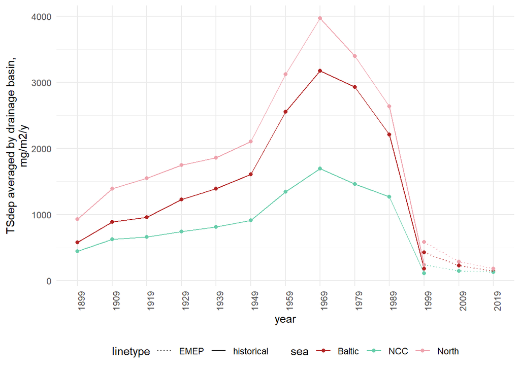

```r
sdep.1899 <- readRDS("sdep.df.1899.rds")@data %>% select(c("gid","tsdep")) %>% mutate(TSdep = (tsdep * (-1) * 365 * 24 * 60 * 60 *1e6), year = "1899", model = "historical")
sdep.1909 <- readRDS("sdep.df.1909.rds")@data %>% select(c("gid","tsdep")) %>% mutate(TSdep = tsdep * (-1) * 365 * 24 * 60 * 60*1e6, year = "1909", model = "historical")
sdep.1919 <- readRDS("sdep.df.1919.rds")@data %>% select(c("gid","tsdep")) %>% mutate(TSdep = tsdep * (-1) * 365 * 24 * 60 * 60*1e6, year = "1919", model = "historical")
sdep.1929 <- readRDS("sdep.df.1929.rds")@data %>% select(c("gid","tsdep")) %>% mutate(TSdep = tsdep * (-1) * 365 * 24 * 60 * 60*1e6, year = "1929", model = "historical")
sdep.1939 <- readRDS("sdep.df.1939.rds")@data %>% select(c("gid","tsdep")) %>% mutate(TSdep = tsdep * (-1) * 365 * 24 * 60 * 60*1e6, year = "1939", model = "historical")
sdep.1949 <- readRDS("sdep.df.1949.rds")@data %>% select(c("gid","tsdep")) %>% mutate(TSdep = tsdep * (-1) * 365 * 24 * 60 * 60*1e6, year = "1949", model = "historical")
sdep.1959 <- readRDS("sdep.df.1959.rds")@data %>% select(c("gid","tsdep")) %>% mutate(TSdep = tsdep * (-1) * 365 * 24 * 60 * 60*1e6, year = "1959", model = "historical")
sdep.1969 <- readRDS("sdep.df.1969.rds")@data %>% select(c("gid","tsdep")) %>% mutate(TSdep = tsdep * (-1) * 365 * 24 * 60 * 60*1e6, year = "1969", model = "historical")
sdep.1979 <- readRDS("sdep.df.1979.rds")@data %>% select(c("gid","tsdep")) %>% mutate(TSdep = tsdep * (-1) * 365 * 24 * 60 * 60*1e6, year = "1979", model = "historical")
sdep.1989 <- readRDS("sdep.df.1989.rds")@data %>% select(c("gid","tsdep")) %>% mutate(TSdep = tsdep * (-1) * 365 * 24 * 60 * 60*1e6, year = "1989", model = "historical")
sdep.1999 <- readRDS("sdep.df.1999.rds")@data %>% select(c("gid","tsdep")) %>% mutate(TSdep = tsdep * (-1) * 365 * 24 * 60 * 60*1e6, year = "1999", model = "historical")
sdep.1999_emep <- readRDS("sdep.1999.rds")@data %>% select(c("gid","tsdep")) %>% mutate(TSdep = tsdep, year = "1999", model = "EMEP")
sdep.2009 <- readRDS("sdep.2009.rds")@data %>% select(c("gid","tsdep")) %>%  mutate(TSdep = tsdep,year = "2009", model = "EMEP")
sdep.2019 <- readRDS("sdep.2019.rds")@data %>% select(c("gid","tsdep")) %>% mutate(TSdep = tsdep,year = "2019", model = "EMEP")

wr.basins <- readRDS("wr.basins.rds")

sdep <- sdep.1899 %>% rbind(sdep.1909) %>% rbind(sdep.1919) %>% rbind(sdep.1929) %>% rbind(sdep.1939) %>% rbind(sdep.1939) %>% rbind(sdep.1949) %>% rbind(sdep.1959) %>% rbind(sdep.1969) %>% rbind(sdep.1979) %>% rbind(sdep.1989) %>% rbind(sdep.1999) %>% rbind(sdep.1999_emep) %>% rbind(sdep.2009) %>% rbind(sdep.2019) %>% merge(st_drop_geometry(wr.basins), by = "gid") %>% group_by(sea,year, model) %>% summarise(TSdep = mean(TSdep, na.rm = T)) %>% filter(!is.na(sea))

ggplot()+geom_point(data = filter(sdep, model == "historical"), aes(x=year, y = TSdep, col = sea))+
         geom_line(data = filter(sdep, model == "historical"),aes(x=year, y = TSdep, col = sea, group = sea, lty = "historical"))+
  geom_point(data = filter(sdep, model == model), aes(x=year, y = TSdep, col = sea))+
         geom_line(data = filter(sdep, model == "EMEP"),aes(x=year, y = TSdep, col = sea, group = sea, lty = model))+
    ylab("TSdep averaged by drainage basin,\nmg/m2/y")+
  scale_color_manual(values = c("firebrick","mediumaquamarine", "lightpink2"))+
  scale_linetype_manual(values = c("dotted", "solid"))+
  theme_minimal()+
  theme(axis.text.x = element_text(angle = 90), legend.position = "bottom")
```

## 2.4 Runoff with NorESM

CMIP6 information: https://pcmdi.llnl.gov/CMIP6/

https://wcrp-cmip.github.io/CMIP6_CVs/docs/CMIP6_source_id_experiment_citation.html

Information on AMIP: https://www.wdc-climate.de/ui/cmip6?input=CMIP6.CMIP.CNRM-CERFACS.CNRM-CM6-1.amip Historical experiment: https://www.wdc-climate.de/ui/cmip6?input=CMIP6.CMIP.CNRM-CERFACS.CNRM-CM6-1.historical

Resolution: 100 km

10 years average

```r
wr.sf <- readRDS("wr.sf.rds")
```

```r
runoff.raster.1 <- "mrros_Lmon_NorESM2-MM_historical_r1i1p1f1_gn_189001-189912.nc"
runoff.raster.2 <- "mrros_Lmon_NorESM2-MM_historical_r1i1p1f1_gn_190001-190912.nc"


runoff.stack.1 <- raster::stack(runoff.raster.1, bands = c(49:120)) # from 1894 to 1899
runoff.stack.2 <- raster::stack(runoff.raster.1, bands = c(1:48)) # from 1900 to 1904
runoff.mean <- raster::stack(runoff.stack.1, runoff.stack.2) %>% mean()

runoff.1899 <- raster::extract(runoff.mean, wr.sf, fun = mean, df = T, sp = T, na.rm = T)

names(runoff.1899) <- c("gid","area","runoff")
saveRDS(runoff.1899,"runoff.1899.noresm.rds")
```

```r
runoff.raster.1 <- "mrros_Lmon_NorESM2-MM_historical_r1i1p1f1_gn_190001-190912.nc"
runoff.raster.2 <- "mrros_Lmon_NorESM2-MM_historical_r1i1p1f1_gn_191001-191912.nc"


runoff.stack.1 <- raster::stack(runoff.raster.1, bands = c(49:120))
runoff.stack.2 <- raster::stack(runoff.raster.1, bands = c(1:48))
runoff.mean <- raster::stack(runoff.stack.1, runoff.stack.2) %>% mean()

runoff.1909 <- raster::extract(runoff.mean, wr.sf, fun = mean, df = T, sp = T, na.rm = T)



names(runoff.1909) <- c("gid","area","runoff")
saveRDS(runoff.1909,"runoff.1909.noresm.rds")
```

```r
runoff.raster.1 <- "mrros_Lmon_NorESM2-MM_historical_r1i1p1f1_gn_191001-191912.nc"
runoff.raster.2 <- "mrros_Lmon_NorESM2-MM_historical_r1i1p1f1_gn_192001-192912.nc"

runoff.stack.1 <- raster::stack(runoff.raster.1, bands = c(49:120))
runoff.stack.2 <- raster::stack(runoff.raster.1, bands = c(1:48))
runoff.mean <- raster::stack(runoff.stack.1, runoff.stack.2) %>% mean()

runoff.1919 <- raster::extract(runoff.mean, wr.sf, fun = mean, df = T, sp = T, na.rm = T)

names(runoff.1919) <- c("gid","area","runoff")
saveRDS(runoff.1919,"runoff.1919.noresm.rds")
```

```r
runoff.raster.1 <- "mrros_Lmon_NorESM2-MM_historical_r1i1p1f1_gn_192001-192912.nc"
runoff.raster.2 <- "mrros_Lmon_NorESM2-MM_historical_r1i1p1f1_gn_193001-193912.nc"

runoff.stack.1 <- raster::stack(runoff.raster.1, bands = c(49:120))
runoff.stack.2 <- raster::stack(runoff.raster.1, bands = c(1:48))
runoff.mean <- raster::stack(runoff.stack.1, runoff.stack.2) %>% mean()

runoff.1929 <- raster::extract(runoff.mean, wr.sf, fun = mean, df = T, sp = T, na.rm = T)


names(runoff.1929) <- c("gid","area","runoff")
saveRDS(runoff.1929,"runoff.1929.noresm.rds")
```

```r
runoff.raster.1 <- "mrros_Lmon_NorESM2-MM_historical_r1i1p1f1_gn_193001-193912.nc"
runoff.raster.2 <- "mrros_Lmon_NorESM2-MM_historical_r1i1p1f1_gn_194001-194912.nc"

runoff.stack.1 <- raster::stack(runoff.raster.1, bands = c(49:120))
runoff.stack.2 <- raster::stack(runoff.raster.1, bands = c(1:48))
runoff.mean <- raster::stack(runoff.stack.1, runoff.stack.2) %>% mean()

runoff.1939 <- raster::extract(runoff.mean, wr.sf, fun = mean, df = T, sp = T, na.rm = T)

names(runoff.1939) <- c("gid","area","runoff")
saveRDS(runoff.1939,"runoff.1939.noresm.rds")
```

```r
runoff.raster.1 <- "mrros_Lmon_NorESM2-MM_historical_r1i1p1f1_gn_194001-194912.nc"
runoff.raster.2 <- "mrros_Lmon_NorESM2-MM_historical_r1i1p1f1_gn_195001-195912.nc"

runoff.stack.1 <- raster::stack(runoff.raster.1, bands = c(49:120))
runoff.stack.2 <- raster::stack(runoff.raster.1, bands = c(1:48))
runoff.mean <- raster::stack(runoff.stack.1, runoff.stack.2) %>% mean()

runoff.1949 <- raster::extract(runoff.mean, wr.sf, fun = mean, df = T, sp = T, na.rm = T)

names(runoff.1949) <- c("gid","area","runoff")
saveRDS(runoff.1949,"runoff.1949.noresm.rds")
```

```r
runoff.raster.1 <- "mrros_Lmon_NorESM2-MM_historical_r1i1p1f1_gn_195001-195912.nc"
runoff.raster.2 <- "mrros_Lmon_NorESM2-MM_historical_r1i1p1f1_gn_196001-196912.nc"

runoff.stack.1 <- raster::stack(runoff.raster.1, bands = c(49:120))
runoff.stack.2 <- raster::stack(runoff.raster.1, bands = c(1:48))
runoff.mean <- raster::stack(runoff.stack.1, runoff.stack.2) %>% mean()

runoff.1959 <- raster::extract(runoff.mean, wr.sf, fun = mean, df = T, sp = T, na.rm = T)


names(runoff.1959) <- c("gid","area","runoff")
saveRDS(runoff.1959,"runoff.1959.noresm.rds")
```

```r
runoff.raster.1 <- "mrros_Lmon_NorESM2-MM_historical_r1i1p1f1_gn_196001-196912.nc"
runoff.raster.2 <- "mrros_Lmon_NorESM2-MM_historical_r1i1p1f1_gn_197001-197912.nc"

runoff.stack.1 <- raster::stack(runoff.raster.1, bands = c(49:120))
runoff.stack.2 <- raster::stack(runoff.raster.1, bands = c(1:48))
runoff.mean <- raster::stack(runoff.stack.1, runoff.stack.2) %>% mean()

runoff.1969 <- raster::extract(runoff.mean, wr.sf, fun = mean, df = T, sp = T, na.rm = T)


names(runoff.1969) <- c("gid","area","runoff")
saveRDS(runoff.1969,"runoff.1969.noresm.rds")
```

```r
runoff.raster.1 <- "mrros_Lmon_NorESM2-MM_historical_r1i1p1f1_gn_197001-197912.nc"
runoff.raster.2 <- "mrros_Lmon_NorESM2-MM_historical_r1i1p1f1_gn_198001-198912.nc"

runoff.stack.1 <- raster::stack(runoff.raster.1, bands = c(49:120))
runoff.stack.2 <- raster::stack(runoff.raster.1, bands = c(1:48))
runoff.mean <- raster::stack(runoff.stack.1, runoff.stack.2) %>% mean()

runoff.1979 <- raster::extract(runoff.mean, wr.sf, fun = mean, df = T, sp = T, na.rm = T)


names(runoff.1979) <- c("gid","area","runoff")
saveRDS(runoff.1979,"runoff.1979.noresm.rds")
```

```r
runoff.raster.1 <- "mrros_Lmon_NorESM2-MM_historical_r1i1p1f1_gn_198001-198912.nc"
runoff.raster.2 <- "mrros_Lmon_NorESM2-MM_historical_r1i1p1f1_gn_199001-199912.nc"

runoff.stack.1 <- raster::stack(runoff.raster.1, bands = c(49:120))
runoff.stack.2 <- raster::stack(runoff.raster.1, bands = c(1:48))
runoff.mean <- raster::stack(runoff.stack.1, runoff.stack.2) %>% mean()

runoff.1989 <- raster::extract(runoff.mean, wr.sf, fun = mean, df = T, sp = T, na.rm = T)

names(runoff.1989) <- c("gid","area","runoff")
saveRDS(runoff.1989,"runoff.1989.noresm.rds")
```

```r
runoff.raster.1 <- "mrros_Lmon_NorESM2-MM_historical_r1i1p1f1_gn_199001-199912.nc"
runoff.raster.2 <- "mrros_Lmon_NorESM2-MM_historical_r1i1p1f1_gn_200001-200912.nc"

runoff.stack.1 <- raster::stack(runoff.raster.1, bands = c(49:120))
runoff.stack.2 <- raster::stack(runoff.raster.1, bands = c(1:48))
runoff.mean <- raster::stack(runoff.stack.1, runoff.stack.2) %>% mean()

runoff.1999 <- raster::extract(runoff.mean, wr.sf, fun = mean, df = T, sp = T, na.rm = T)

names(runoff.1999) <- c("gid","area","runoff")
saveRDS(runoff.1999,"runoff.1999.noresm.rds")
```

```r
runoff.raster.1 <- "mrros_Lmon_NorESM2-MM_historical_r1i1p1f1_gn_200001-200912.nc"
runoff.raster.2 <- "mrros_Lmon_NorESM2-MM_historical_r1i1p1f1_gn_201001-201412.nc"

runoff.stack.1 <- raster::stack(runoff.raster.1, bands = c(49:120))
runoff.stack.2 <- raster::stack(runoff.raster.1, bands = c(1:48))
runoff.mean <- raster::stack(runoff.stack.1, runoff.stack.2) %>% mean()

runoff.2009 <- raster::extract(runoff.mean, wr.sf, fun = mean, df = T, sp = T, na.rm = T)

names(runoff.2009) <- c("gid","area","runoff")
saveRDS(runoff.2009,"runoff.2009.noresm.rds")
```

The historical models in CMIP6 stops in 2014. Surface runoff is available for future projections. We used the projection for SSP245, taking into account the emissions during the COVID years. Also calculated with NorESM.

```r
runoff.raster1 <- "mrros_Lmon_NorESM2-LM_ssp245-covid_r1i1p1f2_gn_201502-202012.nc"
runoff.raster2 <- "mrros_Lmon_NorESM2-LM_ssp245-covid_r1i1p1f2_gn_202101-203012.nc"

runoff.stack1 <- raster::stack(runoff.raster1, bands = c(1:71)) # all layers from 2015 to 2020
runoff.stack2 <- raster::stack(runoff.raster2, bands = c(1:48)) # layers from 2021 to 2024
runoff.mean <-  raster::stack(runoff.stack1, runoff.stack2) %>% mean()

runoff.2019 <- raster::extract(runoff.mean, wr.sf, fun = mean, df = T, sp = T, na.rm = T)

runoff.2019 <- readRDS("runoff.2019.rds")
names(runoff.2019) <- c("gid","area","runoff")
saveRDS(runoff.2019,"runoff.2019.noresm.rds")
```

### 2.4.1 Evolution Runoff

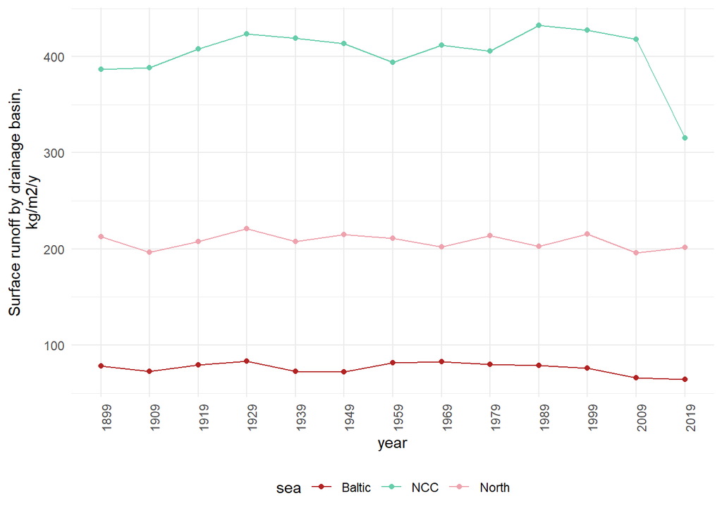

```r
runoff.1899.noresm <- readRDS("runoff.1899.noresm.rds")@data %>% mutate(year = "1899")
runoff.1909.noresm <- readRDS("runoff.1909.noresm.rds")@data %>% mutate(year = "1909")
runoff.1919.noresm <- readRDS("runoff.1919.noresm.rds")@data %>% mutate(year = "1919")
runoff.1929.noresm <- readRDS("runoff.1929.noresm.rds")@data %>% mutate(year = "1929")
runoff.1939.noresm <- readRDS("runoff.1939.noresm.rds")@data %>% mutate(year = "1939")
runoff.1949.noresm <- readRDS("runoff.1949.noresm.rds")@data %>% mutate(year = "1949")
runoff.1959.noresm <- readRDS("runoff.1959.noresm.rds")@data %>% mutate(year = "1959")
runoff.1969.noresm <- readRDS("runoff.1969.noresm.rds")@data %>% mutate(year = "1969")
runoff.1979.noresm <- readRDS("runoff.1979.noresm.rds")@data %>% mutate(year = "1979")
runoff.1989.noresm <- readRDS("runoff.1989.noresm.rds")@data %>% mutate(year = "1989")
runoff.1999.noresm <- readRDS("runoff.1999.noresm.rds")@data %>% mutate(year = "1999")
runoff.2009.noresm <- readRDS("runoff.2009.noresm.rds")@data %>% mutate(year = "2009")
runoff.2019.noresm <- readRDS("runoff.2019.noresm.rds")@data %>% mutate(year = "2019")

noresm <- runoff.1899.noresm %>% rbind(runoff.1909.noresm) %>% rbind(runoff.1919.noresm) %>%
      rbind(runoff.1929.noresm) %>% rbind(runoff.1939.noresm) %>%
      rbind(runoff.1949.noresm) %>% rbind(runoff.1959.noresm) %>%
      rbind(runoff.1969.noresm) %>% rbind(runoff.1979.noresm) %>%
      rbind(runoff.1989.noresm) %>% rbind(runoff.1999.noresm) %>%
      rbind(runoff.2009.noresm) %>% rbind(runoff.2019.noresm)
noresm$Runoff <- noresm$runoff * 365 * 24 * 60 * 60 # convert from kg/m2/s

wr.basins <- readRDS("wr.basins.rds")

noresm.basins <- merge(noresm, st_drop_geometry(wr.basins), by = "gid") %>% group_by(sea,year) %>% summarise(Runoff = mean(Runoff, na.rm = T)) %>% filter(!is.na(sea))

ggplot()+geom_point(data = noresm.basins, aes(x=year, y = Runoff, col = sea))+
         geom_line(data = noresm.basins,aes(x=year, y = Runoff, col = sea, group = sea))+
    ylab("Surface runoff by drainage basin,\nkg/m2/y")+
  scale_color_manual(values = c("firebrick","mediumaquamarine", "lightpink2"))+
  theme_minimal()+
  theme(axis.text.x = element_text(angle = 90), legend.position = "bottom")
```